# Pacific Northwest Summer Adventure

August 2025 Trip Itinerary

Published

# 1 How Ancient Megafloods Shaped Pacific Northwest Cuisine

Between 15,000 and 13,000 years ago, glacial Lake Missoula underwent repeated catastrophic drainage events when ice dams failed. These outburst floods discharged approximately 2,500 cubic kilometers of water, reaching peak discharges of $10^7$ cubic meters per second and flow depths exceeding 120 meters through the Columbia River Gorge.

The Missoula Floods represent the largest documented freshwater discharge events in Earth’s recent geological history. J Harlen Bretz first proposed the catastrophic flood hypothesis in 1923, initially meeting significant resistance from the geological community committed to uniformitarian principles. Subsequent research using paleomagnetic dating, sediment analysis, and hydraulic modeling has confirmed the flood sequence and established its role in landscape formation.

This route traverses the primary flood path and associated landforms, including channeled scablands, flood bars, and rhythmite deposits that preserve a detailed record of Pleistocene hydrological extremes and their influence on regional ecosystem development.

**Why Pacific Northwest Food Tastes Different:**

**Wine Born From Ancient Floods:** Picture a wall of water 400 feet tall carrying boulders the size of houses across the landscape at 60 miles per hour. When Glacial Lake Missoula’s ice dam broke 15,000 years ago, it unleashed the largest flood in Earth’s recorded history. This incredible deluge didn’t just reshape the land - it transported mineral-rich sediment from the Rocky Mountains and deposited it across eastern Washington and Oregon. Today, every glass of Walla Walla wine comes from soil that was literally carried here by the most spectacular flood event our planet has ever witnessed.

**Rivers Shaped by Ice Age Giants:** The Columbia River system is a masterpiece carved by repeated megafloods that occurred dozens of times over 2,000 years. These weren’t ordinary floods - each one dwarfed anything in recorded human history, carving the gorges and creating the perfect gravel beds that salmon have used for spawning for thousands of years. The fish you’ll eat on this trip swim in waters shaped by forces that boggle the mind.

**Volcanic Caves That Age Cheese:** Mount Adams didn’t just create another peak - its eruptions formed natural underground chambers that maintain a perfect 55°F year-round. These lava tube caves now house North America’s only volcanic cave cheese aging operation. Every bite carries mineral signatures from molten rock that once flowed at temperatures over 2,000°F, creating flavors you literally cannot find anywhere else on Earth.

**Glacial Valley Agriculture and Geothermal Systems:** Fertile valleys throughout the route exist because glacial processes created optimal agricultural conditions. Glacial valleys provide natural drainage, glacial till provides mineral-rich soil, and glacial landforms create microclimates necessary for diverse agriculture. Hot springs represent deep geological connections where glacial carving exposed deep crustal fractures, allowing superheated groundwater to reach the surface. Hot spring mineral content—sulfur, calcium, magnesium, trace elements—represents deep earth chemistry that also enriches local soils and water systems.

**Contemporary Cultural Production:** Contemporary arts, hospitality, and maker culture represent different approaches to interpreting and living within these geological conditions. Tyler Hays’s work in Lostine demonstrates how understanding regional materials and processes informs contemporary design. His transformation of Pacific Northwest timber traditions into international luxury markets reflects engagement with local ecological relationships. Luxury hospitality sectors, including Under Canvas glamping operations, represent evolution of human relationship to landscape that builds on indigenous seasonal camping patterns while incorporating contemporary materials and comfort standards.

**Why Pacific Northwest Food Tastes Different:**

**Wine Born From Ancient Floods:** Picture a wall of water 400 feet tall carrying boulders the size of houses across the landscape at 60 miles per hour. When Glacial Lake Missoula’s ice dam broke 15,000 years ago, it unleashed the largest flood in Earth’s recorded history. This incredible deluge didn’t just reshape the land - it transported mineral-rich sediment from the Rocky Mountains and deposited it across eastern Washington and Oregon. Today, every glass of Walla Walla wine comes from soil that was literally carried here by the most spectacular flood event our planet has ever witnessed.

**Rivers Shaped by Ice Age Giants:** The Columbia River system is a masterpiece carved by repeated megafloods that occurred dozens of times over 2,000 years. These weren’t ordinary floods - each one dwarfed anything in recorded human history, carving the gorges and creating the perfect gravel beds that salmon have used for spawning for thousands of years. The fish you’ll eat on this trip swim in waters shaped by forces that boggle the mind.

**Volcanic Caves That Age Cheese:** Mount Adams didn’t just create another peak - its eruptions formed natural underground chambers that maintain a perfect 55°F year-round. These lava tube caves now house North America’s only volcanic cave cheese aging operation. Every bite carries mineral signatures from molten rock that once flowed at temperatures over 2,000°F, creating flavors you literally cannot find anywhere else on Earth.

**Glacial Valley Agriculture and Geothermal Systems:** Fertile valleys throughout the route exist because glacial processes created optimal agricultural conditions. Glacial valleys provide natural drainage, glacial till provides mineral-rich soil, and glacial landforms create microclimates necessary for diverse agriculture. Hot springs represent deep geological connections where glacial carving exposed deep crustal fractures, allowing superheated groundwater to reach the surface. Hot spring mineral content—sulfur, calcium, magnesium, trace elements—represents deep earth chemistry that also enriches local soils and water systems.

## 1.1 Pacific Northwest Culinary Heritage: Smokehouse Culture, Artisan Bakeries and Fire-Roasted Traditions

**Geological Foundations of Regional Food Culture:** The geological processes that shaped this landscape also created ideal conditions for diverse food production. Glacial valleys provide perfect growing conditions for wheat and grains, volcanic soils enrich flavor profiles, and natural mineral springs create optimal conditions for artisan food production. Regional food culture spans from indigenous fire-cooking traditions to European immigrant bakery techniques, creating a unique Pacific Northwest culinary landscape that honors both geological and cultural heritage.

**Smokehouse Heritage and Artisan Cured Meats:**

Traditional Pacific Northwest smokehouses feature alder wood smoking (indigenous tradition using native alder wood), cold-smoking techniques (European methods adapted to local fish), mountain-cured meats (high-altitude dry-aging processes), and wild game preparation (traditional methods for elk, deer, and trout). Regional specialties include Pacific salmon (traditional indigenous smoking methods), mountain trout (cold-smoked with applewood and cherry), grass-fed beef (Montana and Oregon ranch brisket), and heritage pork (slow-smoked using regional hardwoods).

**European-Style Artisan Bakeries and Heritage Breads:** Traditional bread culture features sourdough starters (some dating back to 1800s pioneer settlements), stone-milled flours (local wheat varieties from Palouse region), wood-fired ovens (European-style brick and stone ovens), and seasonal grains (ancient wheat varieties and heritage grains). Regional bread specialties include Pacific Northwest sourdough (tangy, dense loaves with local wheat), multigrain mountain breads (hearty breads with local seeds and grains), rye and spelt loaves (European immigrant traditions), and seasonal fruit breads (incorporating regional berries and apples). Bakery traditions throughout the route feature Montana wheat breads, Idaho potato breads, Oregon artisan loaves, and Washington craft breads.

**Patagonian-Style Fire Cooking and Cross-Roasted Meats:**

**Argentine Asado Techniques in the Pacific Northwest:**

The **cross-roasted lamb** (cordero al palo) tradition has found perfect expression in the Pacific Northwest, where ranchers and chefs have embraced **Patagonian-style fire cooking** methods. This ancient technique involves slow-roasting whole lambs or large cuts on wooden crosses over open fires.

The cross-roasting process involves securing whole lamb or shoulder to wooden cross or spit, hours of slow cooking over carefully managed hardwood fires, continuous basting with herb-infused oils and wine, and temperature control through fire management and positioning. Regional adaptations include Montana ranch lamb from grass-fed animals in Big Sky country, Oregon heritage breeds such as Katahdin and Dorper sheep, Washington wine country lamb paired with local Syrah and Malbec, and Idaho mountain cooking using high-altitude fire-roasting techniques. The perfect Patagonian-style experience features open fire cooking using native Pacific Northwest hardwoods, traditional chimichurri made with regional herbs and oils, family-style serving carved tableside from the cross, and local wine pairings with bold reds from Columbia Valley. Cross-roasted lamb experiences are available at working cattle and sheep ranches, wine country dinners as special vineyard events, mountain lodge seasonal lamb roasts, and chef collaborations between Argentine chefs and local ranchers. The complete asado experience includes afternoon preparation watching lamb preparation and fire building, wine tasting sampling regional wines while meat slow-cooks, traditional sides of grilled vegetables with chimichurri and rustic breads, and communal dining sharing the feast with fellow travelers.

This represents the perfect fusion of **South American fire-cooking traditions** with **Pacific Northwest ingredients and hospitality** - creating unforgettable meals that honor both culinary heritage and regional terroir.

# 2 Route Overview with Geography

## 2.1 Pacific Northwest Adventure Route Map

[figure not shown]

Route Overview Map

**A Journey Through the American West**

**MONTANA**

**BOZEMAN (Aug 3-4)** - Museum of the Rockies, Yellowstone Gateway, Elevation: 4,820 ft

**IDAHO**

**JERRY JOHNSON HOT SPRINGS (Aug 6)** - Lochsa River Valley, Natural soaking pools, Highway 12 Scenic Byway

**MCCALL (Aug 7-8)** - Payette Lake, Payette National Forest, Elevation: 5,021 ft

**OREGON**

**WASHINGTON**

**COLUMBIA RIVER GORGE (Aug 11)** - Columbia River, Cascade Range, Elevation: 200 ft

**SEATTLE (Aug 12-14)** - Puget Sound, Olympic & Cascade Mountains, Elevation: 175 ft

## 2.2 Geographic Context

### 2.2.1 Mountain Ranges Traversed

### 2.2.2 Mountain Ranges Traversed

The route traverses six distinct mountain ranges, each representing different geological formations and evolutionary histories. The Rocky Mountains in Montana encompass the Continental Divide and extend into the Glacier National Park region, providing the foundational geological framework for the northern portion of the journey. The Bitterroot Mountains along the Montana-Idaho border feature Lolo Pass and the Jerry Johnson Hot Springs area, representing the transitional zone between Rocky Mountain and Pacific Northwest geological provinces. The Payette Mountains in Idaho include Brundage Mountain and extensive areas within Payette National Forest, characterized by glacially-carved alpine terrain.

The Wallowa Mountains in Oregon, known as the “Alps of Oregon,” contain the Eagle Cap Wilderness and represent some of the most dramatically glaciated terrain in the region. The Blue Mountains spanning Oregon and Washington provide passage through Umatilla National Forest areas. The Cascade Range in Washington encompasses the Columbia River Gorge and Mount Hood vicinity, representing active volcanic geological processes.

### 2.2.4 Climate Zones Experienced

The route crosses five distinct climate zones, each supporting different ecosystems and reflecting varying geographical influences. Continental climate conditions in Montana feature dry summers and cold winters, reflecting the region’s position within the North American continental interior and distance from maritime influences. Maritime-influenced continental climate in Idaho provides moderate four-season patterns with increased precipitation from Pacific air masses penetrating inland through mountain gaps. High desert climate in eastern Oregon creates hot, dry summer conditions with minimal precipitation, reflecting the rain shadow effects of surrounding mountain ranges. Mediterranean climate around Walla Walla supports wine-growing conditions through warm, dry summers and mild, wet winters similar to Mediterranean Basin climates. Temperate oceanic climate in western Washington produces mild, wet winters and moderate summers, reflecting direct maritime influences from Pacific Ocean air masses.

### 2.2.5 Elevation Profile

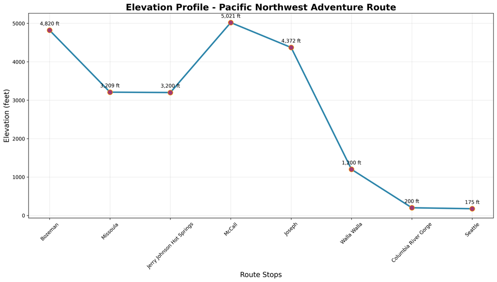

Elevation Profile

The route traverses dramatic elevation changes from Seattle’s sea level (175 ft) to McCall’s mountain elevation (5,021 ft), crossing multiple climate zones and terrain types.

# 3 Route Summary

**Travelers:** Gil, Camila, Aviv, and Smadar (Aviv & Smadar departing Seattle 8/12)  
**Duration:** August 3-14, 2025  
**Route:** Montana → Idaho → Oregon → Washington

| **Leg** | **From** | **To** | **Distance** | **Drive Time** | **Highlights** |
| --- | --- | --- | --- | --- | --- |
| 1 | Bozeman | Missoula | 202 mi | 2h 58m | Montana exploration |
| 2 | Missoula | Jerry Johnson Hot Springs | 66 mi | 1h 20m | Scenic highway route |
| 3 | Jerry Johnson | McCall | 190 mi | 3h 49m | Mountain lakes & forests |
| 4 | McCall | Joseph | 166 mi | 4h 19m | Wallowa Mountains |
| 5 | Joseph | Walla Walla | 109 mi | 2h 11m | Wine country arrival |
| 6 | Walla Walla | Columbia River Gorge | 205 mi | 3h 37m | Scenic gorge drive |
| 7 | Columbia River Gorge | Seattle | 110 mi | 2h 10m | Final destination |

**Total Distance:** 1,049 miles  
**Total Driving Time:** 20.4 hours  
**Average Daily Drive:** 2.9 hours

# 4 Hotel Walking Maps - Quick Reference Guide

This section provides full-page spreads of all walking vicinity maps for easy reference throughout your trip. Each map shows everything within a 30-minute walk of your hotel using high-resolution satellite imagery with street overlays.

## 4.1 Bozeman, Montana Walking Map

**Kimpton Armory Hotel | August 3-4**

[interactive chart not shown]

**Hotel:** Kimpton Armory Hotel | 24 W Mendenhall St | (406) 551-7700

**Within Walking Distance:** - Main Street Historic District - Historic downtown core with shops and galleries - Wild Crumb Bakery - European artisan breads and sourdough culture - Great Harvest Bread Co. - Fresh-milled Montana wheat breads - Blackbird Kitchen - Wood-fired Argentine-style asado and lamb - Montana State University Campus - Historic university grounds - Bogert Park - Green space with trails and recreation - Local breweries and craft beer scene

## 4.2 Missoula, Montana Walking Map

**AC Hotel Missoula Downtown | August 5**

[interactive chart not shown]

**Hotel:** AC Hotel Missoula Downtown | 200 S Pattee St | (406) 541-8000

**Within Walking Distance:** - Clark Fork Riverfront Trail - Scenic riverside walking path - University of Montana Campus - Historic campus with museums - Downtown Historic District - Vibrant downtown with local culture - Le Petit Outre - French pastries and European breads - Plonk Wine Bar - Argentine-inspired cuisine and wine - Higgins Avenue Bridge - Iconic bridge with river views - Local art galleries and cultural sites

## 4.3 McCall, Idaho Walking Map

**Shore Lodge | August 7-8**

[interactive chart not shown]

**Hotel:** Shore Lodge | 501 W Lake St | (800) 657-6464

**Within Walking Distance:** - Payette Lake Beach - Crystal clear mountain lake access - Downtown McCall - Charming mountain town shopping and dining - Smoky Mountain Pizzeria - Wood-fired pizza and mountain atmosphere - Legacy Park - Lakefront park with trails and recreation - McCall Activity Barn - Local recreation and community center - Lakefront promenade and boat rentals - Mountain town galleries and craft shops

## 4.4 Joseph, Oregon Walking Map

**The Jennings Hotel | August 9**

[interactive chart not shown]

**Hotel:** The Jennings Hotel | 100 Main St | (541) 432-0230

**Within Walking Distance:** - Valley Bronze of Oregon - Working bronze foundry with public access - Embers Brewhouse - Local brewery with mountain atmosphere - Main Street Historic District - Authentic western town character - Lear’s Main Street Grill - Local dining and mountain cuisine - Town Park - Community green space and recreation - Artist studios and galleries throughout downtown - Wallowa Mountains viewpoints and photo opportunities

## 4.5 Lostine, Oregon Walking Map

**Day Trip from Joseph | August 9**

[interactive chart not shown]

**Distance from Joseph:** 8 miles north | **Drive Time:** 12 minutes

**Within Walking Distance:** - M. Crow & Co. General Store - Internationally renowned design destination - Lostine Tavern - Authentic Western atmosphere and community hub - Historic Methodist Church - Community cultural center - Main Street Historic Buildings - Original homestead architecture - Lostine River Access - Scenic river walks and fishing - Eagle Cap Wilderness Trailheads - Alpine hiking access - Working cattle ranches - Authentic ranching heritage

## 4.6 Walla Walla, Washington Walking Map

**Eritage Resort | August 10**

[interactive chart not shown]

**Hotel:** Eritage Resort | 1000 N 2nd Ave | (509) 394-4700

**Within Walking Distance:** - Downtown Historic District - Wine country charm and architecture - Farmers Market - Saturday market with local producers and crafts - Colville Street Patisserie - French pastries and artisan breads - Pioneer Park - Historic park with community recreation - Wine Tasting Rooms - Multiple downtown tasting experiences - Historic courthouse and government buildings - Local galleries and wine country culture

## 4.7 Columbia River Gorge Walking Map

**Under Canvas Columbia River | August 11**

[interactive chart not shown]

**Glamping:** Under Canvas Columbia River | Cascade Locks area

**Within Walking Distance of Cascade Locks:** - Bridge of the Gods - Iconic Columbia River bridge crossing - Thunder Island Brewing - Local brewery with river views - Historic Locks and Dam - Engineering marvel and salmon viewing - Marine Park - Riverside park with trails and river access - Columbia River Trail - Scenic walking and biking path - Historic town center with local dining and shops

## 4.8 Seattle, Washington Walking Map

**The Fairmont Olympic Seattle | August 12-14**

[interactive chart not shown]

**Hotel:** The Fairmont Olympic Seattle | 411 University St | (206) 621-1700

**Within Walking Distance:** - Pike Place Market - Iconic market with fresh seafood and crafts - Seattle Art Museum - Premier Pacific Northwest art collection - Pioneer Square - Historic district with underground tours - Waterfront Park - Elliott Bay views and Olympic Sculpture Park - Grand Central Bakery - Artisan sourdough and Pacific Northwest breads - Benaroya Hall - Home of Seattle Symphony - Shopping and dining throughout downtown core

# 5 Bozeman, Montana

## 5.1 Day 1: August 3rd

## 5.2 Bozeman, Montana

**August 3-4 | Elevation: 4,820 ft**

🗺️ **View Bozeman Recommendations Map** - Interactive map showing all recommendations around your hotel

### 5.2.1 Walking Vicinity Map - Downtown Bozeman

🛰️ **View Satellite Walking Map** - Satellite view with 30-minute walking radius from your hotel

This detailed satellite map shows everything within walking distance of Kimpton Armory Hotel, including Main Street Historic District, local bakeries, breweries, parks, and cultural sites. The satellite imagery with street overlays makes it easy to navigate on foot and see the actual terrain and building layouts.

### 5.2.2 Kimpton Armory Hotel Bozeman

Contact (406) 551-7700 | kimptonarmoryhotel.com. Best Room: Mountain View King ($300-450/night). Amenities include boutique luxury, fitness center, and pet-friendly accommodations.

### 5.2.3 Activities

Downtown exploration and local breweries, Montana State University campus, and Museum of the Rockies.

### 5.2.4 Glacial & Geological Features - Montana Leg

**Glacial Lake Missoula Legacy**

The entire Montana route sits within the massive impact zone of Glacial Lake Missoula floods. The Bozeman Area is positioned along the floodplain of the Bozeman pass drainage, showing flood scour marks. Geological evidence includes massive glacial erratics (out-of-place boulders) visible throughout the valley and terrace formations from catastrophic glacial outburst floods occurring approximately 15,000 years ago.

**Visible Glacial Features in Bozeman Area**

Glacial features include terminal and lateral moraines visible on hillsides (especially north of town), large boulders scattered throughout the valley floor, Gallatin Valley filled with glacial sediment deposits, and step-like formations along the Gallatin River from glacial dam-break floods.

**Specific Roadside Geology**

Road views include Interstate 90 approach through glacial-carved valley with visible moraines on both sides, Highway 191 North with glacial cirques visible in the Bridger Mountains, and Bridger Range showing U-shaped glacial valleys and hanging valleys visible from town.

### 5.2.5 Archaeological & Paleontological Sites

**Museum of the Rockies (Bozeman)**

Located on Montana State University campus, the museum features the world’s largest collection of dinosaur fossils, including Maiasaura (Montana’s state fossil). Famous discoveries include the Egg Mountain site with revolutionary dinosaur nesting ground discoveries and interactive Maiasaura “good mother reptile” life-sized models and replica skull exhibits. Hours: 9 AM - 5 PM daily. Admission: $18 adults, $13 seniors/students. Visit to see artifacts from nearby Egg Mountain that changed how paleontologists understand dinosaur behavior.

**Pictograph Cave State Park (90 minutes from Bozeman)**

Located 23 miles southeast of Billings (side trip option), this National Historic Landmark preserves 5,000+ years of human habitation. Features include 100+ pictographs (rock paintings), 30,000+ artifacts excavated, and the oldest art including 2,000-year-old turtle pictograph. Archaeological impact includes the first definitive archaeological report about Northwestern Plains (1951). Trail: 3/4 mile interpretive loop with viewing platforms. Hours: 9 AM - 7 PM (summer), visitor center 10 AM - 5 PM. Admission: $8 non-residents, $4 walk-ins.

### 5.2.6 Bakery Recommendations

**Great Harvest Bread Co.**

Fresh-milled Montana wheat bread and daily artisan loaves. Featured: Montana wheat sourdough, sunflower honey oat. Hours: Mon-Sat 6:30 AM - 6 PM.

**Wild Crumb Bakery & Cafe**

European-style artisan breads with heritage sourdough starter. Featured: Country sourdough, rye breads, ciabatta. Hours: Tues-Sat 7 AM - 3 PM.

### 5.2.7 BBQ & Smokehouse Recommendations

**Bar 3 BBQ & Brewing** | *Belgrade (7 miles from Bozeman)*

Must Try: Montana beef brisket, hickory-smoked pulled pork. Bonus: 10+ craft beers on tap. Hours: Daily 11 AM - 9 PM.

**Blue Smoke Barbeque** | *Bozeman*

Specialty: 100% wood-smoked local meats. Featured: Smoked trout, Montana beef brisket. Hours: Call ahead for availability.

### 5.2.8 Specialty Dining

**Blackbird Kitchen**

Wood-fired Argentine-style asado. Featured: Whole lamb shoulder, cross-roasted meats. Hours: Daily 5 PM - 10 PM.

**Montana Wagyu** (by arrangement)

Custom whole lamb roasts with traditional Patagonian preparation. Farm visits and asado cooking demonstrations available.

## 5.3 Day 2: August 4th

**Bozeman, Montana**

**Additional Archaeological Sites**

**Barton Gulch Archaeological Site (Historical Context)**

Located in Madison County, southwest Montana (Ruby River area), this 9,400-year-old Paleo-Indian site contains 37 archaeological features. Discoveries include Clovis culture artifacts, hunting tools, and earth ovens providing evidence of seasonal semi-nomadic hunter-gatherers. Research was conducted by Montana State University’s Dr. Les Davis (1987-1993). Note: Not open to public, but represents Montana’s oldest archaeological evidence.

**Montana Archaeological Significance**

Human presence in Montana dates back 13,000+ years. Artifacts include stone tools, pottery fragments, and hunting implements from ancestors of modern tribes including Crow, Blackfeet, and others. Evidence shows inter-tribal trade networks spanning Great Basin to Northern Plains.

# 6 Missoula, Montana

## 6.1 Day 3: August 5th

**Missoula, Montana**

🗺️ **View Missoula Recommendations Map** - Interactive map centered on AC Hotel Downtown

### 6.1.1 Walking Vicinity Map - Downtown Missoula

🛰️ **View Satellite Walking Map** - Satellite view with 30-minute walking radius from your hotel

This satellite map shows everything walkable from AC Hotel Missoula Downtown, including the Clark Fork Riverfront Trail, University of Montana campus, downtown historic district, local bakeries, and the scenic Higgins Avenue Bridge. Perfect for exploring Missoula on foot with clear satellite imagery and street overlays.

The optimal room request specifies “high floor, west- or south-facing corner room with panoramic city views, walk-in glass shower, no carpet” to maximize the urban mountain experience. At $455 per room per night, total accommodation cost reaches $910 for both rooms, though availability remains limited requiring prompt reservation. Missoula activities encompass walking the scenic Clark Fork Riverfront Trail, exploring diverse local food establishments throughout downtown, visiting the Rocky Mountain Elk Foundation for wildlife education, and discovering the University of Montana campus with its historic architecture and cultural offerings.

### 6.1.2 **The Revolutionary Geological Discovery: Bretz’s Two Flood Stories**

**This Missoula-Spokane route follows one of geology’s most controversial and revolutionary discoveries. Recent research reveals that J Harlen Bretz actually proposed two different flood theories:**

**1. The Original “Spokane Flood” (1922-1927)**

Age: 150,000 to possibly 1 million years ago. Source: Canadian trench systems (Rocky Mountain trench, Purcell trench). Mechanism: Subglacial flow under the “Spokane Ice Sheet”. Water Path: Down from Canadian trenches, under ice, carving major channels. Evidence: Paleomagnetic dating shows reversed polarity (older than 780,000 years). Impact: Carved Grand Coulee, Moses Coulee, and major scabland channels.

**2. The Later “Missoula Floods” (1927 onward)**

Age: 19,000-15,000 years ago. Source: Glacial Lake Missoula ice dam collapse (Joseph Pardee’s contribution). Mechanism: Proglacial flooding (out in front of ice sheet). Water Path: From Missoula lake through already-carved channels. Evidence: Well-dated sediment layers, rhythmites, current ripples. Impact: Added decorative sediment layers to already-carved landscape.

**Evidence from the Astoria Fan (offshore Oregon)**

One-third of sediment from Missoula floods, two-thirds of sediment from older Spokane floods. Implication: The older floods were twice as massive as all Missoula floods combined.

**The Scientific Partnership**

J Harlen Bretz mapped the effects (scabland channels, flood evidence). Joseph Thomas Pardee identified the cause (glacial Lake Missoula). In 1925, Pardee’s crucial letter suggestion connected 500 cubic miles of lake water to Bretz’s flood evidence. Geographic Connection: Missoula (Pardee’s study area) to Spokane (Bretz’s field site). Together: They solved North America’s greatest geological mystery.

**The Two Geological Giants**

Pardee (1871-1960): USGS geologist, worked western Montana, first to map glacial Lake Missoula. Bretz (1882-1981): University of Chicago professor, mapped channeled scablands, revolutionary catastrophist. Professional Relationship: Cordial scientific correspondence led to breakthrough understanding. Legacy: Their collaboration changed geology from gradualism to accepting catastrophic events.

This route follows the path of both flood stories - the ancient Canadian drainage system that carved the major landscape features over hundreds of thousands of years, and the more recent Missoula flood deposits that left the detailed sediment layers visible today.

### 6.1.3 **Specific Evidence Visible Along This Route:**

**Large Current Ripples on Glacial Lake Missoula Floor**

Massive current ripples are visible across the Missoula valley floor, appearing as wave-like patterns best observed from elevated viewpoints around the city. These enormous ripples reach heights exceeding 20 feet with spacing of more than 300 feet between crests, formed by the catastrophic drainage events that repeatedly emptied glacial Lake Missoula.

**Glacial Lake Missoula Shoreline Terraces**

Step-like formations visible on hillsides surrounding Missoula represent ancient shorelines from multiple lake levels created by repeated dam breaks and refilling cycles. Each horizontal terrace line marks a consistent elevation where the lake surface remained stable, with each terrace representing one complete cycle of lake formation, catastrophic drainage, and refilling.

**Large Glacial Erratics**

Massive out-of-place boulders scattered throughout the route represent Canadian Rockies granite transported far from their original geology. These erratics, some reaching 40 feet in diameter, were carried by icebergs floating in the flood waters and deposited on hillsides as the icebergs melted and grounded during the massive drainage events.

**Paleomagnetic Evidence Sites**

Geological formations in the Morango area of eastern Washington contain flood layers with reversed magnetic polarity, indicating they formed more than 780,000 years ago during Earth’s last magnetic field reversal. This paleomagnetic evidence proves that multiple generations of catastrophic floods occurred across vastly different geological time periods, supporting the theory of both ancient Spokane floods and more recent Missoula floods.

**Rhythmite Layers**

Road cuts along the route expose distinctive alternating layers of coarse gravel and fine silt that record individual flood cycles. Each rhythmite couplet represents one complete flood event, with coarse material deposited during peak flow and fine sediments settling during slack water periods. More than 40 separate flood events spanning 2,000 years are recorded in these sedimentary sequences.

**The Astoria Fan Connection:** All the eroded rock from these floods had to go somewhere - it created a large underwater fan offshore Oregon. Recent drilling reveals that 2/3 of this sediment pile comes from the older Spokane floods, with only 1/3 from the well-known Missoula floods.

### 6.1.4 Archaeological & Cultural Sites

**University of Montana Archaeological Collections**

The University of Montana’s Anthropology Department maintains significant archaeological research collections focused on regional studies and artifact preservation. Ongoing projects examine Northwestern Plains prehistory while offering archaeological field school programs for students. The department regularly displays current research findings and welcomes inquiries about regional archaeological discoveries.

**Historical & Cultural Context**

The Missoula area represents traditional lands of the Salish, Kootenai, and Pend d’Oreille peoples, with archaeological evidence documenting continuous occupation spanning thousands of years. The river valley location provided vital resources for indigenous communities, supporting seasonal camps and permanent settlements. Modern tribal nations continue active cultural preservation efforts, maintaining connections to ancestral landscapes and traditional practices.

**Local Pottery & Artisan Connections**

Downtown Missoula hosts numerous local artists and craft cooperatives showcasing regional talent. Saturday farmers markets feature local ceramics and indigenous-inspired crafts alongside agricultural products. First Friday art walks highlight regional artists working in various media, while the University of Montana ceramics program displays work by Montana clay artists and student practitioners.

### 6.1.5 Artisan Bakeries & Fresh Breads

**Le Petit Outre (Missoula)**

Located at 129 W Front St, Le Petit Outre specializes in French-style pastries and European artisan breads using authentic French pastry techniques. The bakery features pain de campagne, baguettes, croissants, and seasonal tarts, offering genuine French breakfast pastries and European breads in a Montana mountain setting. Open Tuesday through Saturday, 7 AM to 3 PM, this establishment brings authentic French baking traditions to the American West.

**Bernice’s Bakery (Missoula)**

A local institution at 190 S 3rd St W, Bernice’s Bakery has served traditional American baking for decades, specializing in old-fashioned donuts and classic breads. The bakery produces sourdough loaves, dinner rolls, cinnamon rolls, and seasonal specialties using time-tested recipes and methods. Open Monday through Saturday, 6 AM to 6 PM, Bernice’s represents traditional Montana bakery culture with comfort food breads and classic American baking techniques.

### 6.1.6 Incredible Smoked Meats, BBQ & Cheese

**T-Rex BBQ (Three Forks - 30 minutes from Missoula)**

Located at 124 Main St in Three Forks, T-Rex BBQ specializes in what locals call Montana’s pride and joy brisket, described as “some of the best you’ll ever have.” The smokehouse features smoked trout, Montana pork spareribs, and pineapple pork belly burnt ends, with unique offerings including house-recipe jalapeño cheddar sausage and weekend tri-tip roast. Operating Wednesday through Saturday from 11:30 AM to 7 PM (breakfast 6-9 AM), T-Rex represents authentic Montana barbecue using dry rubs that are both gluten and sugar free.

**Riverhouse BBQ (Big Sky - 45 minutes from Missoula)**

Situated along the Gallatin River in Big Sky, Riverhouse BBQ combines authentic Texas barbecue techniques with Montana mountain setting, specializing in mesquite smoking methods. The restaurant features smoked trout, Hill Country barbecue, and dry-rubbed meats served with riverside dining and dramatic Spanish Peaks views. Open daily from 3 PM to 9 PM in winter and 3 PM to 10 PM in summer, Riverhouse offers mesquite-smoked meats in one of Montana’s most stunning mountain river settings.

### 6.1.7 Patagonian-Style Lamb & Cross-Roasted Meats

**Plonk Wine Bar (Missoula)**

Located at 322 N Higgins Ave, Plonk Wine Bar specializes in Argentine-inspired small plates and wine selections, featuring grilled lamb prepared with chimichurri and paired with carefully selected wines. The establishment offers extensive Argentine wine selections alongside South American culinary influences, creating a wine country atmosphere focused on lamb preparations and regional pairings. Open daily from 4 PM to midnight, Plonk brings Argentine dining culture to Montana’s wine bar scene.

**Local Ranch Connections (Missoula Area)**

Bitterroot Valley ranches, located approximately 30 minutes south of Missoula, offer custom lamb orders and ranch visit experiences featuring grass-fed Montana lamb and ranch-to-table dining. These working ranches provide authentic agricultural experiences including lamb preparation demonstrations and farm-to-table meals showcasing regional livestock production. Special arrangements can be made directly with local ranches for visitors seeking authentic Montana ranch experiences and premium locally-raised lamb.

# 7 Jerry Johnson Hot Springs

## 7.1 Day 4: August 6th

**Jerry Johnson Hot Springs**

[figure not shown]

Route: Missoula to Jerry Johnson Hot Springs

[figure not shown]

Route: Jerry Johnson Hot Springs to McCall

### 7.1.1 Archaeological & Cultural Sites Along Highway 12

**Kelly Creek Archaeological Site (Historical Context)**

Located in Clearwater National Forest near the Montana-Idaho border, the Kelly Creek Archaeological Site contains 12,000-year-old artifacts representing some of Idaho’s oldest evidence of human occupation. University of Idaho excavations conducted between 2009-2012 uncovered more than 11,000 artifacts including projectile points, spear tips, and stone tools spanning from the Windust phase (earliest regional period) through historic times. The site served as seasonal hunting and fishing grounds for ancestors of the Nez Perce and Coeur d’Alene peoples, with obsidian tools demonstrating extensive trade networks across the Pacific Northwest. While not open to public visitation, this research site represents significant regional archaeological importance in understanding early human adaptation to mountain environments.

**Indigenous Cultural Landscape**

The Highway 12 corridor passes through traditional Nez Perce and Coeur d’Alene territory, where these peoples established seasonal camps and conducted systematic resource gathering for thousands of years. Natural hot springs held both spiritual and practical importance in indigenous culture, with traditional knowledge of thermal resources passed through generations of tribal members. Modern tribal nations continue active cultural preservation and education efforts, maintaining connections to ancestral landscapes and traditional ecological knowledge.

**Nez Perce Cultural Heritage**

The Highway 12 corridor traverses ancestral Nez Perce lands, where sophisticated resource management systems developed around understanding seasonal resource cycles across diverse mountain and plateau environments. Extensive trading relationships connected Nez Perce communities across the Columbia Plateau, facilitating exchange of goods, knowledge, and cultural practices. Active tribal efforts continue today to maintain traditional practices and educate both tribal and non-tribal communities about indigenous cultural heritage and ongoing connections to traditional territories.

### 7.1.2 Route Details: Highway 12 Scenic Drive

Highway 12, also known as the Northwest Passage Scenic Byway, offers spectacular mountain driving through the Lochsa Wild and Scenic River corridor with sweeping views of the Selway-Bitterroot Wilderness. The total driving time spans 3-4 hours including the hot springs stop, following paved mountain roads with curves requiring careful driving. This scenic route follows traditional indigenous travel corridors that connected Columbia Plateau and Northern Plains cultures for thousands of years.

### 7.1.3 Glacial & Geological Features - Highway 12 Route

**Lochsa River Valley Glacial Corridor**

The Highway 12 route follows the Lochsa River through a classic glacial valley characterized by the perfect U-shaped profile carved by glacial ice over multiple ice ages. This extremely deep canyon, reaching depths of 4,000 feet, displays typical glacial erosion patterns with distinct absence of V-shaped river cutting that would characterize stream-carved valleys. The broad valley floor and steep sides represent the hallmark characteristics of glacial carving processes.

**Specific Glacial Features Along Highway 12**

At Powell Junction, glacial cirque basins become visible in surrounding peaks, while the Lowell Area displays glacial outwash terraces and moraines from multiple ice advances. The Lochsa River follows the glacial valley floor with typical glacial meandering patterns, while the Bitterroot Range exhibits glacial horns and arêtes visible on ridge tops throughout the drive.

**Alpine Glacial Features**

Bowl-shaped depressions carved by glacial ice in high country form glacial cirques, while hanging valleys represent tributary valleys positioned higher than the main valley floor. Glacial moraines consist of rock debris deposited by glacial ice movement, and glacial striations preserve scratch marks on exposed bedrock surfaces created by glacial movement carrying rock fragments.

**Hot Springs Geological Context**

Thermal activity in the region associates with deep crustal fractures exposed and enhanced by glacial carving processes. Geothermal systems became accessible through glacial erosion that removed overlying rock layers, while water sources derive from snowmelt infiltrating through glacial deposits and bedrock fractures to reach heated zones at depth.

# 8 McCall, Idaho

## 8.1 Day 5-6: August 7th-8th

**Shore Lodge, McCall**

🗺️ **View McCall Recommendations Map** - Interactive map showing hot springs, dining, and activities around Shore Lodge

### 8.1.1 Walking Vicinity Map - McCall Town Center

🛰️ **View Satellite Walking Map** - Satellite view with 30-minute walking radius from Shore Lodge

This satellite map shows the beautiful lakefront setting of Shore Lodge and everything walkable in McCall, including Payette Lake Beach, downtown shops and restaurants, Legacy Park, and the charming mountain town atmosphere. The satellite imagery clearly shows the lake, forest, and town layout for easy navigation.

Shore Lodge is a luxury lakefront resort located in McCall, Idaho, at 5,021 feet elevation on Payette Lake, offering two-night accommodations with premium amenities and services. The resort can be reached at shorelodge.com or (800) 657-6464, with recommended room requests for lakefront suites featuring panoramic lake views, fireplaces, and private balconies. Room options include Lakefront Suites with full lake views, fireplaces, and balconies ($500-700/night) or Premium Lake View rooms with partial lake views and luxury amenities ($400-600/night). Resort amenities encompass spa services, fine dining, concierge assistance, and direct lakefront access for recreational activities.

Resort dining centers on Narrows Steakhouse, serving wood-fired steaks, smoked mountain game, and Idaho trout daily from 5:30 PM to 10 PM, while the concierge can arrange custom dining experiences including Patagonian-style lamb roasts and outdoor cooking demonstrations. Hot spring day trips include Trail Creek Hot Springs with two rock pools accessed via a 60-foot walk from parking, Burgdorf Hot Springs featuring a historic resort with three pools ($20/adult, reservations required), and Gold Fork Hot Springs offering six tiered crystal pools ($10/adult). Special services encompass spa treatments, mountain wellness programs, and lakefront activities including kayaking and paddleboarding.

### 8.1.2 Archaeological & Cultural Sites

**Wilson Butte Cave (South-central Idaho)**

Located in Twin Falls County approximately two hours south of McCall, Wilson Butte Cave represents an important Paleo-Indian archaeological site with significant research value. Excavations conducted in 1959-1960 and 1988-1989 revealed evidence of human occupation spanning thousands of years, providing crucial insights into early hunter-gatherer societies and habitation patterns. University studies continue to analyze findings from this research site, which remains closed to public tours but contributes substantially to understanding prehistoric human adaptation in the region.

**Celebration Park (Day Trip Option - 3 hours south)**

Canyon County’s Celebration Park, located near the Snake River, holds the distinction of being Idaho’s only archaeological park since its establishment in 1989. The park features petroglyphs ranging from 100 to 10,000 years old preserved in basalt melon gravels, with activities including atlatl demonstrations where visitors can try throwing ancient hunting tools, interpretive trails with archaeological displays, and guided tours of petroglyphs offered daily from 10 AM to 2 PM. The park exists within Bonneville Flood geological formations, with a visitor center providing educational displays on Paleolithic and Archaic lifeways. Admission costs $2 per vehicle with camping available, offering visitors hands-on archaeological experiences with ancient hunting demonstrations.

**Hells Canyon Archaeological Context (Eastern Idaho)**

Hells Canyon National Recreation Area contains significant archaeological discoveries, including a 600-year-old Nez Perce textile cache discovered in 2008 that contained cedar bark weaving materials and basket components. The canyon preserves evidence of indigenous occupation spanning more than 13,000 years, representing seasonal hunting, fishing, and resource gathering areas used by successive indigenous cultures. Modern tribal nations maintain active cultural preservation efforts connected to these ancestral sites, ensuring continuity of traditional knowledge and practices linked to this remarkable landscape.

### 8.1.3 Glacial & Geological Features - McCall & Payette Lake

**Payette Lake Glacial Formation**

Payette Lake formed through glacial damming and carving processes, reaching depths of 314 feet typical of glacial lake formation. The surrounding valley was carved by multiple glacial advances over thousands of years, with terminal and lateral moraines visible around the lake perimeter marking the extent of ice sheet movement and deposition.

**McCall Area Glacial Features**

Brundage Mountain displays glacial cirques and moraines visible on modern ski slopes, while Payette National Forest preserves extensive glacial features throughout the high country. Multiple U-shaped glacial valleys radiate from McCall, creating the characteristic alpine topography, with numerous high-country lakes formed by glacial carving processes scattered throughout the mountainous terrain.

**Payette Mountains Glacial Legacy**

Bowl-shaped basins carved by glacial ice in high peaks form distinctive glacial cirques, while sharp peaks resulted from glacial carving attacking mountains from multiple sides to create glacial horns. Sharp ridges formed between glacial cirques create glacial arêtes, and smooth bedrock surfaces throughout the region preserve evidence of glacial grinding and polishing during ice sheet movement.

**Hot Springs Geological Context - McCall Area**

Multiple hot springs systems around the McCall area emerge from deep geological fractures, with geothermal activity enhanced by glacial carving that exposed previously buried geothermal systems. These thermal features produce mineral-rich waters from deep earth sources, creating therapeutic soaking opportunities that combine geological processes with recreational activities.

### 8.1.4 Artisan Bakeries & Fresh Breads

**Pancake House & Christmas Shop (McCall)**

Located at 209 N 3rd St, the Pancake House & Christmas Shop specializes in fresh-baked goods and traditional breakfast breads, serving as a local institution with decades of reputation in the McCall community. The establishment features sourdough pancakes, cinnamon rolls, fresh muffins, and daily bread made from scratch, offering hearty breakfast breads and mountain comfort food. Open daily from 7 AM to 2 PM, this traditional mountain bakery represents authentic local baking culture with time-tested recipes and methods.

**Rupert’s at Hotel McCall**

Situated at 1101 N 3rd St within Hotel McCall, Rupert’s specializes in artisan breads and European-style pastries prepared by a professional pastry chef. The hotel bakery features fresh-baked bread, croissants, and seasonal pastries, offering elegant breakfast pastries and artisan bread in a luxury mountain setting. Operating daily from 7 AM to 11 AM during breakfast service, Rupert’s provides professional-quality baking that combines European techniques with mountain hospitality.

### 8.1.5 Incredible Smoked Meats, BBQ & Cheese

**Shore Lodge Narrows Steakhouse**

Located at 501 W Lake St within Shore Lodge, the Narrows Steakhouse specializes in wood-fired steaks and smoked mountain game, featuring Idaho trout, smoked salmon, dry-aged steaks, and local game in an exceptional lakefront dining setting with stunning mountain views. The restaurant excels in fresh mountain fish and premium smoked meats, operating daily from 5:30 PM to 10 PM and providing luxury mountain dining with exceptional smoked fish preparations that showcase regional ingredients and smoking traditions.

**Smoky Mountain Pizzeria & Smokehouse (McCall)**

Located at 815 N 3rd St, Smoky Mountain Pizzeria & Smokehouse specializes in wood-fired pizza and house-smoked meats, featuring unique offerings like smoked trout pizza, BBQ brisket, smoked salmon, and mountain sausages prepared using wood-fired ovens and traditional mountain smoking techniques. The establishment excels in smoked fish specialties and mountain BBQ, operating daily from 11 AM to 10 PM and representing local smoking traditions combined with authentic wood-fired cooking methods that showcase regional ingredients and time-honored techniques.

### 8.1.6 Patagonian-Style Lamb & Cross-Roasted Meats

**Shore Lodge Custom Dining**

Shore Lodge resort offers custom asado experiences and outdoor cooking through their concierge services, specializing in whole lamb roasts, open-fire cooking, and lakefront dining experiences with private chef services and custom fire cooking arrangements. These special occasion lamb experiences provide authentic asado dining in a luxury resort setting, available through Shore Lodge concierge for private dining arrangements that combine custom Argentine-style cooking with pristine lakefront mountain ambiance.

**Local Ranch Connections (McCall Area)**

Meadows Valley ranches, located 45 minutes south of McCall, specialize in grass-fed lamb and authentic ranch experiences, featuring mountain lamb production, ranch tours, and working farm visits in high-altitude grazing environments with pristine mountain settings. These farm-to-table lamb operations provide authentic ranch experiences for visitors seeking direct connections to Idaho mountain lamb production, with special arrangements available through contact with local ranches for immersive agricultural tourism experiences.

### 8.1.7 Pottery & Artisan Studios in McCall Area

**Local Pottery & Artisan Connections**

The McCall area features numerous local ceramic artists and seasonal craft fairs through McCall Arts & Crafts, while Payette National Forest preserves traditional pottery techniques and indigenous crafts knowledge. Summer farmers markets showcase local ceramics alongside agricultural products, and regional artist cooperatives support ceramic artists working with clay and traditional materials, creating a vibrant artisan community centered around traditional and contemporary pottery practices.

**Indigenous-Inspired Arts**

Cultural education programs offer workshops on traditional pottery techniques, while contemporary artists create modern interpretations inspired by indigenous designs and traditional knowledge preservation efforts. Collaborative projects between Native and non-Native artists foster cultural exchange and artistic innovation, ensuring that traditional pottery knowledge continues to influence contemporary ceramic arts practice in the region.

### 8.1.8 Artisan Workshop Access & Creative Ateliers

**Valley County Artist Community**

The Valley County artist community maintains working studios, pottery studios, woodworking shops, and textile arts practices throughout the area, with local artists’ workshops and ateliers providing space for ceramic artists working with regional clay and glazes, mountain craftspeople working with local timber, and fiber artists and weavers using regional materials in their creative practice.

**Informal Workshop Access**

Seasonal studio tours and informal visits provide artist open studio experiences, while local artisans offer craft demonstrations showing traditional techniques and apprentice opportunities for learning traditional mountain crafts. Community workshops offer drop-in classes and collaborative projects that welcome visitors to participate in regional artistic traditions and learn from experienced local craftspeople.

**Mountain Craft Traditions**

Traditional mountain crafts encompass timber arts working with local pine, fir, and cedar, stone carving using regional granite and volcanic stone, metalwork including blacksmithing and ironwork traditions, and leather crafts using materials from local ranch operations, preserving and continuing time-honored techniques adapted to mountain environments and available materials.

# 9 Joseph, Oregon

## 9.1 Day 7: August 9th

**The Jennings Hotel, Joseph**

🗺️ **View Joseph Recommendations Map** - Interactive map showing Wallowa Lake, bronze foundry, and mountain dining around Jennings Hotel

### 9.1.1 Walking Vicinity Map - Joseph Town Center

🛰️ **View Satellite Walking Map** - Satellite view with 30-minute walking radius from Jennings Hotel

This satellite map showcases Joseph’s charming Main Street location and everything within walking distance of Jennings Hotel, including Valley Bronze foundry, arts center, local restaurants, and the historic western town atmosphere. The satellite view clearly shows the mountain valley setting and small-town layout.

### 9.1.2 Archaeological & Cultural Sites

**Nez Perce National Historical Park (Wallowa Valley)**

Located in the Wallowa Valley of Oregon, the Nez Perce National Historical Park preserves the ancestral homeland of the Nez Perce people, documenting more than 13,000 years of continuous indigenous habitation and serving as the birthplace and homeland of Chief Joseph (Hin-mah-too-yah-lat-kekt). Cultural features include traditional fishing sites on Wallowa Lake, seasonal hunting and gathering areas, sacred sites and ceremonial grounds, and traditional root gathering areas that supported sustainable indigenous lifeways for millennia. The park offers interpretive trails and cultural education programs that connect visitors to this rich cultural heritage, while the Nez Perce tribe maintains active cultural preservation efforts that ensure traditional knowledge and practices continue to inform park interpretation and management.

**Wallowa Lake Archaeological Context**

Located at the end of Wallowa Valley, Wallowa Lake preserves a 10,000+ year archaeological record documenting continuous indigenous occupation through discoveries of stone tools, fishing implements, and seasonal camp sites. Evidence shows continuous seasonal use of the area as a summer fishing and gathering destination, with ongoing university studies examining seasonal habitation patterns and cultural adaptations to alpine environments. Protected archaeological sites around the lake ensure preservation of this significant cultural record for future research and cultural education.

**Old Chief Joseph Gravesite**

The Old Chief Joseph Gravesite in Wallowa Valley marks the burial site of Chief Joseph’s father (Tuekakas), the leader who signed the 1855 Treaty establishing the Wallowa Reservation. This sacred site holds profound cultural importance for the Nez Perce people, featuring a stone marker commemorating his peaceful leadership and diplomatic efforts. Respectful viewing with cultural interpretation provides visitors with understanding of Nez Perce leadership and the complex history of treaty negotiations in the Pacific Northwest.

### 9.1.3 Glacial & Geological Features - Wallowa Mountains

**Wallowa Mountains Glacial Formation**

Extensive glacial carving created the dramatic alpine landscape of the Wallowa Mountains through multiple U-shaped valleys carved by glacial ice, bowl-shaped basins in high peaks from glacial carving, and terminal and lateral moraines distributed throughout the valley system. This glacial sculpturing over multiple ice ages produced the distinctive “Alps of Oregon” topography that characterizes the region today.

**Wallowa Lake Glacial Origin**

Wallowa Lake formed through glacial damming and carving processes, reaching depths of 283 feet typical of glacial lake formation, with the valley floor scoured by glacial ice movement and moraine deposits forming a natural dam at the lake outlet. This glacial origin explains the lake’s exceptional depth and the characteristic steep-walled valley that contains it.

**Eagle Cap Wilderness Glacial Features**

The Eagle Cap Wilderness preserves more than 50 high-country lakes formed by glacial carving, along with sharp peaks formed by glacial carving from multiple sides (glacial horns), sharp ridges formed between glacial cirques (glacial arêtes), and smooth bedrock surfaces from glacial grinding (glacial polish). These features represent some of the most spectacular alpine glacial landscapes in the Pacific Northwest.

**Wallowa Mountains Geological Context**

The Wallowa Mountains consist primarily of granite and metamorphic rocks, with glacial carving exposing diverse geological formations and revealing gold and copper deposits through glacial activity. Structural features including faults and fractures were enhanced by glacial processes, creating the complex geological landscape that supports both the dramatic scenery and the mineral wealth that attracted early settlement to the region.

### 9.1.4 Artisan Bakeries & Fresh Breads

**Embers Brewhouse & Eatery (Joseph)**

Located at 204 N Main St, Embers Brewhouse & Eatery specializes in fresh-baked breads and artisan pizzas, featuring sourdough breads, pizza crusts, fresh rolls, and daily pastries prepared using wood-fired ovens and mountain grain breads. The establishment excels in artisan pizza breads and mountain bakery goods, operating daily from 11 AM to 9 PM as a local institution known for wood-fired bread baking that combines traditional techniques with regional ingredients.

**Wallowa Lake Lodge Dining**

Situated at 60060 Wallowa Lake Hwy, Wallowa Lake Lodge Dining specializes in fresh breakfast breads and mountain pastries, featuring cinnamon rolls, fresh muffins, breakfast breads, and scones prepared in a historic lodge setting with traditional mountain baking methods. The lodge provides lakefront breakfast and mountain comfort food experiences, operating daily from 7 AM to 2 PM for breakfast and lunch service in an authentic historic mountain lodge atmosphere with traditional baking practices.

### 9.1.5 Incredible Smoked Meats, BBQ & Cheese

**Lear’s Main Street Grill (Joseph)**

Located at 111 W Main St, Lear’s Main Street Grill specializes in smoked meats and mountain BBQ, featuring smoked brisket, pulled pork, smoked salmon, and mountain sausages prepared using local smoking traditions and mountain game processing techniques. The restaurant excels in authentic mountain BBQ and smoked specialties, operating daily from 11 AM to 9 PM as a local smokehouse that preserves traditional mountain BBQ traditions and regional smoking methods.

**Wallowa Lake Lodge Smokehouse**

Situated at 60060 Wallowa Lake Hwy, Wallowa Lake Lodge Smokehouse specializes in fresh-smoked fish and mountain game, featuring smoked trout, salmon, elk, venison, and local cheeses prepared using lakefront smoking and traditional techniques. The smokehouse excels in fresh mountain fish and smoked game preparations, operating daily from 5 PM to 10 PM for dinner service as a traditional mountain smokehouse offering lake-fresh fish in an authentic alpine setting.

### 9.1.6 Patagonian-Style Lamb & Cross-Roasted Meats

**Local Ranch Connections (Wallowa Valley)**

Wallowa Valley ranches offer grass-fed lamb and authentic ranch experiences through arrangements coordinated via the Joseph visitor center, featuring mountain lamb production, ranch tours, and working farm visits in high-altitude grazing environments with pristine alpine settings. These farm-to-table lamb operations provide authentic ranch experiences showcasing Oregon mountain lamb in the spectacular valley setting, with special arrangements available through direct contact with local ranches for immersive agricultural tourism experiences.

**Wallowa Valley Festival of Arts (August Timing)**

The Wallowa Valley Festival of Arts takes place in downtown Joseph during August, specializing in outdoor cooking demonstrations and artisan food experiences featuring live cooking, local lamb, artisan foods, and craft demonstrations. This unique artist community event focuses on culinary arts integration, providing cultural experiences with food artistry that showcase the intersection of creative and culinary traditions. Visitors should check the August festival schedule for special events that highlight the artist community’s commitment to food and craft integration.

### 9.1.7 Pottery & Artisan Studios in Joseph

**Valley Bronze of Oregon**

Located at 18 S Main St, Valley Bronze of Oregon specializes in bronze casting and sculptural arts, featuring bronze sculptures, casting demonstrations, and artist workshops in a working foundry with public access. The facility excels in metal arts and sculptural techniques, operating Monday through Saturday from 9 AM to 5 PM as an active foundry that provides visitors with direct access to bronze casting expertise and live demonstrations of traditional metalworking processes.

**Josephy Center for Arts & Culture**

Situated at 403 N Main St, the Josephy Center for Arts & Culture specializes in local pottery and cultural arts, featuring ceramic workshops, pottery classes, and cultural exhibits in a community arts center with comprehensive educational programs. The center excels in pottery learning and cultural engagement, operating Tuesday through Saturday from 10 AM to 5 PM as a community arts hub that provides pottery education and cultural programming that connects visitors to regional artistic traditions.

### 9.1.8 Artisan Workshop Access & Creative Ateliers

**The Jennings Hotel Artist Residency**

**Wallowa Valley Artist Community**

The Wallowa Valley artist community maintains working studios, pottery studios, woodworking shops, and textile arts practices throughout Joseph, with local artists’ workshops and ateliers providing space for ceramic artists working with regional clay and glazes, mountain craftspeople working with local timber, and fiber artists and weavers using regional materials in their creative practices.

**Informal Workshop Access**

Seasonal studio tours and informal visits provide artist open studio experiences, while local artisans offer craft demonstrations showing traditional techniques and apprentice opportunities for learning traditional mountain crafts. Community workshops offer drop-in classes and collaborative projects that welcome visitors to participate in regional artistic traditions and learn from experienced local craftspeople.

**Mountain Craft Traditions**

Traditional mountain crafts encompass bronze work including foundry arts and metal sculpture, timber arts working with local pine, fir, and cedar, stone carving using regional granite and volcanic stone, and leather crafts using materials from local ranch operations, preserving and continuing time-honored techniques adapted to mountain environments and available materials.

## 9.2 Lostine, Oregon - Historic Ranching Town

**Distance from Joseph:** 8 miles north | **Drive Time:** 12 minutes | **Elevation:** 3,640 ft

🗺️ **View Interactive Lostine Town Map** - Detailed map showing all points of interest in this charming mountain town

**Why Visit Lostine:**

Lostine represents the authentic spirit of Oregon’s ranching heritage, where working cattle ranches still define the valley’s character and way of life. This small mountain town serves as both a gateway to the Eagle Cap Wilderness and a showcase of high-end design culture, creating a unique blend of rugged frontier history and sophisticated contemporary artistry. The town’s main street preserves the atmosphere of a classic Western ranching community while hosting one of the region’s most celebrated design destinations.

**Historic Character:**

The town embodies the legacy of 19th-century homesteading and cattle ranching that shaped the entire Wallowa Valley. Original homestead buildings and working ranches surround the town, preserving traditional agricultural practices and architectural heritage that date back to the 1870s. The Lostine River flows through the center of town, providing the water resources that made settlement possible and continue to support both agricultural operations and recreational activities for visitors seeking authentic mountain town experiences.

**M. Crow & Co. General Store - Design Destination**

This internationally renowned design store operates out of a restored historic building on Main Street, showcasing handcrafted furniture and home goods created by Tyler Hays and his design team. The store represents a unique fusion of Pacific Northwest materials and traditional craftsmanship techniques, producing furniture and objects that have gained recognition in major design publications worldwide. Visitors can explore working studios and observe artisans creating contemporary pieces using traditional woodworking and metalworking methods.

**Local Culture:**

Lostine Tavern serves as the social hub of the community, offering hearty mountain fare in an authentic Western atmosphere where locals and visitors gather to experience genuine small-town hospitality. The historic Methodist Church anchors the community’s cultural life, representing the spiritual and architectural heritage that has sustained mountain communities for generations. Community events and gatherings preserve the collaborative spirit essential to ranching culture and mountain living.

**Outdoor Access:**

The town provides direct access to Wallowa-Whitman National Forest through Lostine Canyon Road, leading to trailheads for alpine lake hiking and Eagle Cap Wilderness exploration. The Lostine River offers excellent fishing opportunities and scenic relaxation areas where visitors can experience the pristine mountain environment that defines this region. Multiple hiking trails begin just minutes from town, providing access to some of Oregon’s most spectacular alpine scenery.

**Ranch Heritage:**

Working cattle ranches continue operating throughout the Lostine Valley, maintaining traditional ranching practices and preserving the agricultural landscape that has characterized this area for more than 150 years. Visitors can observe authentic ranching operations and understand the relationship between land use, water management, and sustainable agriculture that sustains both the local economy and the valley’s scenic character. Many ranches welcome respectful visitors interested in learning about modern ranching and land stewardship practices.

**Planning Your Visit:**

Lostine makes an excellent addition to any Joseph area itinerary, offering a deeper understanding of regional culture and access to unique shopping and dining experiences not available in larger towns. The short drive from Joseph allows for easy exploration of both communities, with Lostine providing a more intimate and authentic small-town atmosphere. Plan to spend 2-3 hours exploring the town, visiting M. Crow & Co., and enjoying the peaceful mountain setting that embodies the best of Oregon’s ranching heritage.

# 10 Walla Walla, Washington

## 10.1 Day 8: August 10th

**Eritage Resort, Walla Walla**

🗺️ **View Walla Walla Recommendations Map** - Interactive map showing wineries, historic sites, and wine country dining around Eritage Resort

### 10.1.1 Walking Vicinity Map - Downtown Walla Walla

🛰️ **View Satellite Walking Map** - Satellite view with 30-minute walking radius from Eritage Resort

This satellite map displays the beautiful wine country setting and everything walkable from Eritage Resort, including downtown historic district, wine tasting rooms, French bakeries, Pioneer Park, and the Whitman College campus. The satellite imagery shows the valley landscape and urban layout perfect for exploring on foot.

### 10.1.2 Archaeological & Cultural Sites

**Whitman Mission National Historic Site**

Located at 328 Whitman Mission Rd, the Whitman Mission National Historic Site preserves the 1836 mission established by Dr. Marcus and Narcissa Whitman, documenting early pioneer settlement and cultural exchange as a significant meeting point of indigenous and pioneer cultures. Ongoing archaeological research includes excavations of mission buildings, while the visitor experience features an interpretive center with cultural exhibits and educational programs offering living history demonstrations and cultural education for understanding early cultural interactions in the Pacific Northwest.

**Fort Walla Walla Museum**

Situated at 755 Myra Rd, Fort Walla Walla Museum preserves the military fort established in 1856, documenting 19th-century military and pioneer history through cultural features including a pioneer village with historic buildings, military artifacts and exhibits, archaeological displays from regional excavations, and traditional crafts demonstrations. The visitor experience encompasses historic buildings and living history programs that provide educational value focused on pioneer-era crafts and cultural preservation.

**Cayuse Indigenous Cultural Heritage**

The Walla Walla Valley region represents the ancestral homeland of the Cayuse people, preserving more than 10,000 years of continuous indigenous habitation through cultural features including traditional fishing sites on the Walla Walla River, seasonal hunting and gathering areas, sacred sites and ceremonial grounds, and traditional root gathering areas for camas and bitterroot. Modern connections include active cultural preservation by the Confederated Tribes of Umatilla, with visitor education programs offering cultural interpretation and tribal connections that maintain living relationships to ancestral landscapes.

### 10.1.3 Glacial & Geological Features - Walla Walla Valley

**Walla Walla Valley Glacial Formation**

The Walla Walla Valley formed through Missoula Floods that deposited rich sediments throughout the valley, creating deep alluvial deposits from glacial lake draining that formed exceptional wine-growing soils and carved the current valley configuration through repeated glacial flooding events.

**Blue Mountains Glacial Features**

The Blue Mountains preserve bowl-shaped basins in high peaks from glacial carving (glacial cirques), U-shaped valleys carved by glacial ice movement, terminal and lateral moraines throughout the region, and high-country lakes formed by glacial carving processes.

**Walla Walla River Glacial Context**

Glacial flooding carved the Walla Walla River channel, creating step-like terraces from glacial lake levels, alluvial fans from glacial sediment deposits from mountain runoff, and excellent groundwater storage systems within glacial deposits.

**Wine Country Geological Context**

The wine country rests on Columbia River basalt bedrock underlying the valley, with rich glacial deposits perfect for viticulture, drainage patterns created by glacial shaping that provide excellent vineyard drainage, and a glacial valley configuration that creates the unique wine terroir of the region.

### 10.1.4 Artisan Bakeries & Fresh Breads

**Colville Street Patisserie**

Located at 1425 Plaza Way, Colville Street Patisserie specializes in French pastries and artisan breads, featuring croissants, sourdough, baguettes, and seasonal pastries prepared by a European-trained pastry chef using traditional techniques. The patisserie excels in authentic French breads and elegant pastries, operating Tuesday through Saturday from 7 AM to 3 PM and providing professional French baking in a wine country setting.

**Bright’s Candies & Bakery**

Situated at 226 E Main St, Bright’s Candies & Bakery specializes in traditional breads and sweet treats, featuring fresh daily bread, dinner rolls, sweet breads, and cookies produced by a family bakery with decades of tradition. The bakery excels in classic American breads and hometown baking, operating Monday through Saturday from 8 AM to 6 PM as a historic bakery that maintains traditional recipes and community connections.

**Walla Walla Bread Company**

Located at 1717 E Isaacs Ave, Walla Walla Bread Company specializes in artisan sourdough and heritage grains, featuring natural sourdough, whole grain breads, and ancient grains produced through natural fermentation and local grain sourcing. The bakery excels in artisan sourdough culture and heritage breads, operating Monday through Friday from 7 AM to 5 PM and Saturday from 8 AM to 4 PM as an artisan bakery committed to traditional sourdough methods.

### 10.1.5 Incredible Smoked Meats, BBQ & Cheese

**Smoke & Mirrors**

Located at 1555 E Isaacs Ave, Smoke & Mirrors specializes in artisan smoked meats and craft BBQ, featuring smoked brisket, pulled pork, smoked salmon, and artisan sausages prepared using wine country smoking techniques with local wine pairings. The restaurant excels in gourmet BBQ and wine country dining, operating Wednesday through Sunday from 11 AM to 8 PM and providing elevated BBQ with wine country sophistication that combines traditional smoking methods with regional culinary refinement.

**Walla Walla Cheese Company**

With multiple locations throughout the Walla Walla Valley, Walla Walla Cheese Company specializes in artisan cheeses and local dairy products, featuring farmstead cheeses, aged cheeses, fresh cheeses, and wine pairings produced by local dairy farms using traditional cheesemaking methods. The company excels in wine and cheese pairings and local dairy tradition, with hours varying by location and representing local cheesemaking with a wine country focus that showcases regional dairy heritage.

**Jacoby’s Storehouse**

Situated at 624 2nd Ave, Jacoby’s Storehouse specializes in smoked fish and gourmet foods, featuring smoked salmon, smoked trout, artisan meats, and local cheeses prepared in a historic building using traditional smoking methods. The storehouse excels in Pacific Northwest smoking and gourmet selections, operating Monday through Saturday from 10 AM to 6 PM as a historic smokehouse that preserves regional specialties and traditional food preservation techniques.

### 10.1.6 Patagonian-Style Lamb & Cross-Roasted Meats

**Saffron Mediterranean Kitchen**

Located at 125 W Alder St, Saffron Mediterranean Kitchen specializes in Mediterranean grilling and lamb specialties, featuring grilled lamb, Mediterranean spices, and fire-roasted vegetables prepared using Mediterranean techniques with local ingredients. The restaurant excels in lamb specialties and fire-grilled cuisine, operating Tuesday through Saturday from 5 PM to 9 PM and providing Mediterranean lamb preparation with local sourcing that honors traditional Mediterranean cooking methods.

**Local Ranch Connections (Walla Walla Valley)**

Located throughout the Walla Walla Valley (contact visitor center for locations), local ranches specialize in grass-fed lamb and ranch experiences, featuring valley lamb, ranch tours, and working farm visits that showcase wine country grazing in a pristine valley environment. The ranches excel in farm-to-table lamb and authentic ranch experiences, requiring contact with local ranches for special arrangements and offering Washington valley lamb in a wine country setting that demonstrates sustainable agriculture.

**Walla Walla Farmers Market (Saturday)**

Situated at 4th Ave & Main St, the Walla Walla Farmers Market specializes in local lamb and artisan foods, featuring fresh lamb, local ranchers, artisan foods, and craft demonstrations that provide direct access from ranchers with community connections. The market excels in meeting local producers and providing fresh lamb, operating Saturdays from 9 AM to 1 PM seasonally as a community market with direct ranch connections that strengthen local food systems.

### 10.1.7 Pottery & Artisan Studios in Walla Walla

**Downtown Walla Walla Art Galleries**

Located at multiple locations on Main St, the downtown art galleries specialize in local pottery and regional arts, featuring ceramic arts, pottery classes, and gallery exhibits that showcase wine country arts with multiple gallery spaces. The galleries excel in regional pottery and art gallery tours, with hours varying by gallery and representing a concentrated art district with multiple pottery studios that celebrate regional artistic traditions.

**Walla Walla Community College Fine Arts**

Located at 500 Tausick Way, Walla Walla Community College Fine Arts specializes in pottery education and ceramic arts, featuring pottery classes, ceramic workshops, and student exhibitions that provide college-level instruction with community access. The program excels in pottery learning and ceramic education, with hours varying by program and offering educational pottery with community access that bridges academic and community artistic engagement.

### 10.1.8 Artisan Workshop Access & Creative Ateliers

**Walla Walla Artist Studio Community**

The artist studio community encompasses local artists’ workshops and ateliers throughout downtown, pottery studios where ceramic artists work with regional clay and glazes, woodworking shops where craftspeople work with local timber, and textile arts featuring fiber artists and weavers using regional materials that create a vibrant creative ecosystem in the wine country setting.

**First Friday Art Walk**

Located throughout downtown Walla Walla, the First Friday Art Walk specializes in monthly art walks with open studios, featuring artist studios, gallery openings, and craft demonstrations that create a community event with artist interaction. The event excels in meeting local artists and studio visits, occurring the first Friday of each month from 5 PM to 8 PM as an active art community with monthly celebrations that strengthen cultural connections.

**Informal Workshop Access**

The informal workshop system includes artist open studios with seasonal studio tours and informal visits, craft demonstrations where local artisans demonstrate traditional techniques, apprentice opportunities for learning traditional wine country crafts, and community workshops offering drop-in classes and collaborative projects that foster artistic learning and community engagement.

**Wine Country Craft Traditions**

The wine country craft traditions encompass cooperage focused on barrel-making and wood arts, metalwork including vineyard metalwork and artistic ironwork, stone carving using regional basalt and stone, and leather crafts working with local ranch leather and hides that preserve traditional skills while serving modern wine country needs.

# 11 Columbia River Gorge

## 11.1 Day 9: August 11th

**Under Canvas Columbia River Gorge**

🗺️ **View Columbia River Gorge Recommendations Map** - Interactive map showing waterfalls, breweries, and lodges around Under Canvas glamping

### 11.1.1 Walking Vicinity Map - Cascade Locks

🛰️ **View Satellite Walking Map** - Satellite view of Cascade Locks town

This satellite map shows the dramatic Columbia River Gorge setting and everything walkable in Cascade Locks, including the iconic Bridge of the Gods, historic locks and dam, Thunder Island Brewing, and the riverside marine park. The satellite imagery clearly shows the river, cliffs, and historic infrastructure of this unique gorge town.

Located in Cascade Locks, Oregon, Under Canvas provides one night of luxury glamping resort accommodation at 200 ft elevation in the Columbia River Gorge (website: undercanvas.com/camps/columbia-river-gorge, phone: (888) 496-1148). The best tent request would be a deluxe safari tent with gorge views, private bathroom, and king bed, with tent types including Safari Deluxe featuring gorge views, private bathroom, and king bed ($300-500/night), and Stargazer tents with transparent roof panels and luxury amenities ($400-600/night). The resort specializes in glamping with dramatic gorge views and outdoor adventure, offering activities including waterfall tours, hiking, Bridge of the Gods, and wind sports that showcase the magnificent Columbia River Gorge landscape.

### 11.1.2 Archaeological & Cultural Sites

**Petroglyph Beach & Tsagaglalal (She Who Watches)**

Located at Columbia Hills State Park, Washington, this 10,000+ year archaeological site preserves ancient petroglyphs with evidence of continuous indigenous habitation, featuring the famous Tsagaglalal - “She Who Watches” - iconic rock art. The cultural features include ancient petroglyphs and pictographs, traditional fishing sites, seasonal gathering areas, and sacred ceremonial locations, with visitor experiences featuring guided tours of petroglyphs (reservations required) and active cultural preservation by local tribes for viewing some of the oldest rock art in North America.

**Cascade Locks Historic District**

Located in Cascade Locks, Oregon, this historic district preserves the 1896 locks and dam system on the Columbia River, representing an engineering marvel of 19th-century transportation that transformed river transportation and salmon runs. Ongoing archaeological research studies pre-dam cultural sites, while the visitor experience includes an interpretive center with locks history and educational programs featuring engineering and cultural history demonstrations for understanding human impact on river systems.

**Bonneville Dam Cultural Heritage**

Located between Bonneville, Oregon and Washington, this 1937 dam construction represents New Deal era engineering and cultural change, featuring cultural elements including fish ladder and salmon viewing, visitor center with cultural exhibits, archaeological displays from dam construction, and traditional fishing site interpretations. The visitor experience focuses on fish viewing and cultural education, providing educational value about dam impact on indigenous fishing rights and the transformation of traditional river use patterns.

### 11.1.3 Glacial & Geological Features - Columbia River Gorge

**Columbia River Gorge Glacial Formation**

The Columbia River Gorge formed through catastrophic Missoula Floods that carved the gorge through glacial lake outburst floods, massive ice dams and flooding that carved canyon walls, glacial sediments deposited throughout the gorge, and geological processes occurring 15,000-13,000 years ago during the last ice age.

**Waterfall Glacial Context**

The waterfall formations reflect glacial processes including Multnomah Falls as a 620-foot waterfall enhanced by glacial carving, Latourell Falls where glacial carving exposed Columbia River basalt, Bridal Veil Falls created by glacial valley carving, and Wahkeena Falls where glacial processes enhanced water flow patterns.

**Crown Point & Vista House Geological Context**

Crown Point and Vista House showcase glacial carving that created dramatic cliffs and viewpoints, Columbia River basalt formations exposed by glacial scouring, glacial erratics as boulder deposits from glacial transport, and valley formation where glacial processes carved the current gorge configuration.

**Wind Patterns & Glacial Legacy**

The wind patterns reflect glacial legacy through gorge winds created by glacial carving that produces a wind tunnel effect, windsurfing conditions where glacial valley shape creates consistent winds, weather patterns influenced by glacial geography affecting regional climate, and microclimates created by glacial carving that established unique ecological zones.

### 11.1.4 Artisan Bakeries & Fresh Breads

**Cascade Locks Ale House & Restaurant**

Located at 599 WaNaPa St, Cascade Locks Ale House & Restaurant specializes in fresh-baked breads and pub fare, featuring artisan rolls, pizza crusts, fresh bread, and seasonal pastries with gorge views and outdoor dining. The restaurant excels in casual dining and fresh baked goods, operating daily from 11 AM to 9 PM and providing a gorge setting with fresh daily baking that combines scenic beauty with artisan bread production.

**Stevenson, WA Bakery Options (15 minutes north)**

Located in Stevenson, Washington, these bakery options specialize in small-town bakeries and fresh goods, featuring daily bread, pastries, and coffee accompaniments from community bakeries with local character. The bakeries excel in authentic small-town and fresh baking, with hours varying by location and representing local community with traditional baking that preserves neighborhood bakery traditions.

**Hood River Bakery Connections (20 minutes east)**

Located in Hood River, Oregon, the bakery connections specialize in artisan breads and gorge specialties, featuring sourdough, whole grain breads, and seasonal specialties from a gorge location with mountain views. The bakeries excel in mountain town atmosphere and artisan quality, with hours varying by location and representing gorge town with quality bakeries that showcase regional baking excellence.

### 11.1.5 Incredible Smoked Meats, BBQ & Cheese

**Thunder Island Brewing**

Located at 515 WaNaPa St, Thunder Island Brewing specializes in smoked meats and craft beer, featuring smoked brisket, pulled pork, smoked salmon, and local cheeses in a gorge setting with outdoor smoking. The brewery excels in BBQ and beer with river views, operating daily from 11 AM to 10 PM as a gorge brewery with quality smoked meats that combines craft brewing with traditional smoking techniques.

**Bonneville Hot Springs Resort Dining**

Located at 1252 E Cascade Dr, North Bonneville, Bonneville Hot Springs Resort Dining specializes in smoked salmon and Pacific Northwest cuisine, featuring cedar plank salmon, smoked trout, local game, and artisan cheeses at a hot springs resort with gorge views. The resort excels in elegant dining and smoked fish specialties, operating daily from 5 PM to 9 PM as resort dining with gorge salmon tradition that honors Pacific Northwest culinary heritage.

**Local Smokehouse Connections**

Located at various locations in the Columbia River Gorge, local smokehouse connections specialize in traditional salmon smoking and Native American techniques, featuring cedar plank salmon, alder-smoked fish, and traditional methods that showcase indigenous smoking traditions and river connections. The smokehouses excel in authentic Northwest and traditional techniques, requiring contact with local tribal cultural centers for demonstrations and representing traditional smoking with cultural connections that preserve ancestral food practices.

### 11.1.6 Patagonian-Style Lamb & Cross-Roasted Meats

**Skamania Lodge**

Located at 1131 SW Skamania Lodge Way, Stevenson, Skamania Lodge specializes in fire-grilled meats and outdoor cooking, featuring grilled lamb, fire-roasted vegetables, and outdoor dining in a lodge atmosphere with gorge views. The lodge excels in special occasion dining and fire-grilled cuisine, operating daily from 5 PM to 10 PM as a luxury lodge with fire-grilled specialties that combines elegant dining with dramatic gorge scenery.

**Local Ranch Connections (Gorge Area)**

Located at Columbia River Gorge ranches, local ranch connections specialize in grass-fed lamb and ranch experiences, featuring gorge lamb, ranch tours, and working farm visits that showcase gorge grazing in a river valley environment. The ranches excel in farm-to-table lamb and authentic ranch experiences, requiring contact with local ranches for special arrangements and offering gorge lamb in a dramatic river setting that demonstrates sustainable agriculture.

**Outdoor Cooking Demonstrations**

Located at various gorge locations, outdoor cooking demonstrations specialize in open-fire cooking and outdoor techniques, featuring fire-roasted lamb, outdoor cooking classes, and traditional methods in a gorge setting with natural cooking opportunities. The demonstrations excel in learning outdoor cooking and fire techniques, requiring contact with local outdoor programs for demonstrations and representing gorge setting with outdoor cooking traditions that preserve wilderness culinary skills.

### 11.1.7 Pottery & Artisan Studios in Columbia River Gorge

**Stevenson, WA Artist Community**

Located in Stevenson, Washington, the artist community specializes in local pottery and regional arts, featuring ceramic arts, pottery classes, and gallery exhibits that showcase small-town arts with gorge inspiration. The community excels in regional pottery and community connections, with hours varying by artist and representing community arts with gorge setting that captures the natural beauty of the Columbia River Gorge.

**Hood River, OR Artist Studios (20 minutes east)**

Located in Hood River, Oregon, the artist studios specialize in mountain pottery and artisan studios, featuring ceramic arts, pottery workshops, and artist studios that showcase mountain town arts with gorge views. The studios excel in mountain pottery and studio visits, with hours varying by studio and representing mountain arts community with gorge connections that blend alpine and river valley influences.

**Gorge Artists Open Studios**

Located at various locations throughout the Columbia River Gorge, gorge artists open studios specialize in regional pottery and gorge-inspired arts, featuring ceramic arts, pottery demonstrations, and artist visits that showcase gorge setting with landscape inspiration. The studios excel in regional arts and scenic inspiration, operating during seasonal open studio events and representing gorge artists with natural inspiration that transforms dramatic landscapes into artistic expression.

### 11.1.8 Artisan Workshop Access & Creative Ateliers

**Columbia River Gorge Artist Community**

The Columbia River Gorge Artist Community encompasses local artists’ workshops and ateliers throughout the gorge, pottery studios where ceramic artists work with regional clay and glazes, woodworking shops where craftspeople work with local timber, and textile arts featuring fiber artists and weavers using regional materials that create a vibrant creative ecosystem inspired by the dramatic gorge landscape.

**Gorge Outdoor Education Centers**

Located at various gorge locations, gorge outdoor education centers specialize in outdoor skills and traditional crafts, featuring wilderness skills, traditional crafts, and outdoor workshops that provide gorge setting with outdoor education. The centers excel in learning outdoor skills and traditional techniques, requiring contact with local outdoor programs for workshop schedules and representing gorge setting with outdoor craft traditions that preserve wilderness skills within spectacular natural settings.

**Informal Workshop Access**

The informal workshop access includes artist open studios with seasonal studio tours and informal visits, craft demonstrations where local artisans demonstrate traditional techniques, apprentice opportunities for learning traditional gorge crafts, and community workshops offering drop-in classes and collaborative projects that foster artistic learning and creative community engagement throughout the Columbia River Gorge.

**Gorge Craft Traditions**

The gorge craft traditions encompass stone carving using regional basalt and Columbia River stone, woodworking with Douglas fir and local timber, metalwork including blacksmithing and ironwork traditions, and fiber arts working with regional wool and natural fibers that preserve traditional skills while drawing inspiration from the unique materials and landscapes of the Columbia River Gorge region.

# 12 Seattle, Washington

## 12.1 Day 10-12: August 12th-14th

**The Fairmont Olympic Seattle**

🗺️ **View Seattle Recommendations Map** - Interactive map showing Pike Place Market, neighborhoods, and restaurants around Fairmont Olympic

### 12.1.1 Walking Vicinity Map - Downtown Seattle

🛰️ **View Satellite Walking Map** - Satellite view with 30-minute walking radius from Fairmont Olympic

This satellite map reveals the urban setting and everything walkable from The Fairmont Olympic Seattle, including Pike Place Market, Seattle Art Museum, Pioneer Square, the waterfront, Olympic Sculpture Park, and Benaroya Hall. The satellite imagery shows the city grid, Elliott Bay waterfront, and downtown landmarks perfect for urban exploration on foot.

Located in Seattle, Washington, The Fairmont Olympic Seattle provides two nights of accommodation in a historic luxury hotel from 1924 at sea level at Puget Sound (website: fairmont.com/seattle, phone: (206) 621-1700). The best room request would be a high floor Olympic Suite with city views, luxury amenities, and historic charm, with room types including Olympic Suite featuring city views, luxury amenities, and historic details ($400-600/night), and Deluxe City View rooms with high floor, downtown views, and premium location ($300-500/night). This hotel represents historic elegance, iconic status, and the perfect capstone to a luxury journey, offering activities including Pike Place Market, Space Needle, ferry tours, and museums, specializing in urban exploration with Pacific Northwest culture in a historic luxury setting.

**Twin Peaks Stop - North Bend (August 12th)**

Located in North Bend, Washington (30 minutes from Seattle), this famous Twin Peaks filming location offers featured stops including Salish Lodge & Spa as The Great Northern Lodge from the series, Twede’s Cafe as The RR Diner where Agent Cooper enjoyed “damn fine coffee,” and North Bend scenic overlooks featuring Snoqualmie Falls and Twin Peaks landscapes. The location excels for TV series fans and Pacific Northwest scenery, providing the opportunity to experience the iconic Twin Peaks atmosphere and stunning Cascade mountain views that defined the series’ atmospheric setting.

### 12.1.2 Archaeological & Cultural Sites

**Burke Museum of Natural History and Culture**

Located at the University of Washington, Seattle, the Burke Museum serves as the premier Pacific Northwest archaeological and cultural museum, preserving more than 10,000 years of Pacific Northwest indigenous history through featured collections including Pacific Northwest indigenous artifacts, archaeological discoveries from regional excavations, traditional art and cultural objects, and contemporary indigenous art. The visitor experience encompasses interactive exhibits and cultural education programs, while educational programs offer workshops on indigenous culture and archaeology, making this a comprehensive destination for Pacific Northwest cultural heritage.

**Daybreak Star Cultural Center**

Located in Discovery Park, Seattle, the Daybreak Star Cultural Center serves as an American Indian cultural center and gathering place dedicated to contemporary indigenous cultural preservation, featuring programs including traditional craft demonstrations, cultural education workshops, art exhibitions and cultural events, and traditional food and cooking demonstrations. The visitor experience focuses on cultural programs and indigenous art, providing educational value about modern indigenous culture and traditions as an active indigenous cultural center with educational programs that maintain living cultural connections.

**Pioneer Square Historic District**

Located in downtown Seattle, Pioneer Square Historic District preserves the original Seattle settlement and archaeological site, documenting 1850s pioneer settlement and cultural development through cultural features including historic buildings and architecture, underground tours of original streets, archaeological displays from early settlement, and pioneer-era artifacts and exhibits. The visitor experience includes historic walking tours and underground exploration, while educational programs focus on pioneer history and urban archaeology that reveals the layers of Seattle’s founding and development.

### 12.1.3 Glacial & Geological Features - Seattle & Puget Sound

**Puget Sound Glacial Formation**

Puget Sound formed through massive glacial ice sheet carving that reached depths of 930 feet from glacial scouring, occurring 15,000-13,000 years ago during the last ice age and creating the current sound geography through glacial retreat processes that shaped the distinctive marine landscape of the Pacific Northwest.

**Seattle Hills Glacial Context**

Seattle’s distinctive topography reflects glacial processes including the seven hills formed by glacial deposits creating glacial drumlins, the city built on extensive glacial sediments and deposits known as glacial till, large boulders transported by glacial ice and deposited as glacial erratics, and step-like formations from glacial lake levels creating the glacial terraces that characterize the urban landscape.

**Mount Rainier Glacial Connection**

Mount Rainier’s glacial system connects to regional glaciation through Mount Rainier glaciers that fed the Puget Sound ice sheet, glacial carving that created current mountain valleys, glacial meltwater that carved current river systems, and glacial deposits visible throughout the region as moraines that document the extent and retreat of the massive ice sheets.

**Elliott Bay Glacial Context**

Elliott Bay formed through glacial ice movement that carved the bay configuration, with bay depth resulting from glacial scouring and carving processes, harbor sediments derived from glacial deposits, and the current shoreline shaped by glacial processes that created the distinctive marine environment surrounding Seattle.

### 12.1.4 Artisan Bakeries & Fresh Breads

**Grand Central Bakery**

Located at multiple Seattle locations, Grand Central Bakery specializes in artisan sourdough and European-style breads, featuring natural sourdough, whole grain breads, and seasonal specialties produced using traditional fermentation and local grain sourcing. The bakery excels in artisan bread culture and fermentation expertise, operating daily from 6:30 AM to 6 PM as a Seattle institution with traditional bread making that has defined the city’s artisan baking standards for decades.

**Macrina Bakery**

Located at multiple Seattle locations, Macrina Bakery specializes in artisan pastries and fresh breads, featuring croissants, sourdough, seasonal pastries, and specialty breads created using European techniques with Pacific Northwest ingredients. The bakery excels in elegant pastries and artisan breads, operating daily from 7 AM to 7 PM and representing Seattle bakery excellence with European tradition that combines Old World techniques with regional ingredients.

**Tall Grass Bakery**

Located at 1579 15th Ave, Tall Grass Bakery specializes in organic breads and heritage grains, featuring organic sourdough, ancient grains, and whole grain breads produced with organic certification and sustainable practices. The bakery excels in organic baking and sustainable bread production, operating Wednesday through Sunday from 8 AM to 3 PM as an organic bakery with sustainable focus that demonstrates environmental responsibility in artisan bread making.

### 12.1.5 Incredible Smoked Meats, BBQ & Cheese

**Pike Place Market - Pure Food Fish Market**

Located at Pike Place Market, Seattle, Pure Food Fish Market specializes in fresh-smoked salmon and Pacific Northwest fish, featuring cedar plank salmon, smoked salmon, dungeness crab, and local oysters prepared using market tradition with fish throwing demonstrations. The market excels in fresh Pacific fish and market experience, operating daily from 6:30 AM to 6 PM as an iconic market with fresh smoked fish that represents the quintessential Seattle seafood experience.

**Beecher’s Handmade Cheese**

Located at Pike Place Market, Seattle, Beecher’s Handmade Cheese specializes in artisan cheeses and traditional cheesemaking, featuring flagship cheddar, fresh curds, aged cheeses, and mac and cheese produced through visible cheesemaking and daily production. The cheese company excels in artisan cheese and traditional techniques, operating daily from 9 AM to 7 PM and providing opportunities to watch cheesemaking and taste fresh cheese in the heart of Seattle’s most famous market.

**Westman’s Bagel & Coffee**

Located at 2954 4th Ave S, Westman’s Bagel & Coffee specializes in smoked fish bagels and Pacific Northwest flavors, featuring smoked salmon bagels, lox, cream cheese, and Pacific specialties that showcase Pacific Northwest bagels with local fish. The establishment excels in regional bagel culture and smoked fish, operating daily from 6 AM to 4 PM and representing local bagel tradition with Pacific Northwest fish that creates a distinctive regional breakfast experience.

### 12.1.6 Patagonian-Style Lamb & Cross-Roasted Meats

**Asado (Ballard)**

Located at 2810 NW Market St, Asado specializes in Argentine grilling and authentic asado, featuring grilled lamb, Argentine beef, fire-roasted vegetables, and chimichurri prepared using authentic Argentine techniques with Pacific Northwest ingredients. The restaurant excels in authentic asado and Argentine lamb, operating daily from 5 PM to 10 PM and providing authentic Argentine cuisine with Pacific Northwest connections that honor traditional South American grilling methods.

**Matt’s in the Market**

Located at 94 Pike St, Matt’s in the Market specializes in fire-grilled meats and market-fresh ingredients, featuring grilled lamb, fire-roasted vegetables, and market ingredients sourced from its Pike Place Market location with fire-grilled cuisine. The restaurant excels in market-to-table dining and fire-grilled specialties, operating daily from 5 PM to 10 PM as a market restaurant with fire-grilled excellence that showcases the best of Pike Place Market ingredients.

**Local Ranch Connections (Puget Sound Area)**

Located throughout the Puget Sound region, local ranch connections specialize in grass-fed lamb and authentic ranch experiences, featuring Sound region lamb, ranch tours, and working farm visits that showcase coastal grazing in a Pacific Northwest environment. These ranches excel in farm-to-table lamb and authentic ranch experiences, requiring contact with local ranches for special arrangements and offering Pacific Northwest lamb in a unique coastal setting that demonstrates sustainable agriculture practices within the region’s distinctive maritime climate.

### 12.1.7 Pottery & Artisan Studios in Seattle

**Georgetown Studios**

Located in Georgetown neighborhood, Seattle, Georgetown Studios specializes in artist studios and pottery workshops, featuring ceramic arts, pottery classes, and artist studios in an industrial arts district with multiple studios. The studios excel in urban pottery and studio visits, with hours varying by studio and representing a concentrated arts district with pottery focus that transforms industrial spaces into vibrant creative environments.

**Pottery Northwest**

Located at 226 1st Ave S, Pottery Northwest specializes in community pottery and ceramic education, featuring pottery classes, ceramic workshops, and community studios through a community organization with educational focus. The organization excels in pottery learning and community connection, with hours varying by program and providing community pottery with educational programs that make ceramic arts accessible to all skill levels.

**Vermillion Art Gallery & Bar**

Located at 1508 11th Ave, Vermillion Art Gallery & Bar specializes in local pottery and artisan exhibitions, featuring ceramic arts, pottery exhibitions, and artist receptions in a gallery and bar with local pottery focus. The venue excels in local pottery and artist community, operating daily from 4 PM to 2 AM and providing a social pottery scene with local artists that combines art appreciation with social gathering.

### 12.1.8 Artisan Workshop Access & Creative Ateliers

**Seattle Artist Studio Community:**

The Seattle Artist Studio Community encompasses local artists’ workshops and ateliers throughout Seattle, pottery studios where ceramic artists work with regional clay and glazes, woodworking shops where craftspeople work with Pacific Northwest timber, and textile arts featuring fiber artists and weavers using regional materials that create a diverse urban creative ecosystem reflecting the city’s artistic innovation.

**First Thursday Art Walk**

Located in Pioneer Square, Seattle, the First Thursday Art Walk specializes in monthly art walks with open studios, featuring artist studios, gallery openings, and craft demonstrations that create a monthly community event with artist interaction. The event excels in meeting local artists and studio visits, occurring the first Thursday of each month from 6 PM to 9 PM as an active arts community with monthly celebrations that strengthen cultural connections throughout the historic district. This monthly community event provides unique opportunities for direct artist interaction through open studios, with featured artist studios, gallery openings, and craft demonstrations that represent an active arts community with monthly celebration that builds lasting cultural connections.

**Fremont Arts District**

Located in Fremont neighborhood, Seattle, the Fremont Arts District specializes in quirky arts and creative workshops, featuring artist studios, creative workshops, and unusual arts in a bohemian arts district with creative energy. The district excels in alternative arts and creative exploration, with hours varying by studio and representing a creative neighborhood with artistic diversity that celebrates unconventional artistic expression and community creativity.

**Informal Workshop Access**

The informal workshop access includes artist open studios with seasonal studio tours and informal visits, craft demonstrations where local artisans demonstrate urban techniques, apprentice opportunities for learning contemporary city crafts, and community workshops offering drop-in classes and collaborative projects that foster artistic learning and creative community engagement throughout Seattle’s neighborhoods.

**Seattle Craft Traditions**

The Seattle craft traditions encompass woodworking with Douglas fir and Pacific Northwest timber, metalwork including industrial and artistic metalwork traditions, glassblowing representing Pacific Northwest glass arts, and fiber arts working with regional wool and sustainable materials that preserve traditional skills while embracing urban innovation and environmental consciousness.

# 13 Geological Field Guide & Learning Journey

## 13.1 Understanding Your Route Through Deep Time

This journey traces one of Earth’s most dramatic geological stories - the catastrophic drainage of Glacial Lake Missoula and the subsequent Ice Age Floods that reshaped the Pacific Northwest. As you travel, you’re following the exact path of these ancient floods, observing landscapes carved by forces almost beyond comprehension.

### 13.1.1 Geological Pattern Recognition Guide: Reading Ancient Catastrophes in Stone

**Ancient Flood Pattern Identification versus Normal River Erosion**

The landscape throughout the Pacific Northwest preserves evidence of the most catastrophic floods in Earth’s recent history through distinctive geological patterns that can be identified and interpreted through systematic observation and analysis.

### 13.1.2 Catastrophic Flood Signatures and Missoula Flood Characteristics

Giant current ripples in Washington and Oregon appear as massive sand dune patterns reaching heights of 30 to 50 feet, identifiable by their scale that far exceeds anything possible for normal river systems and could only be created by 400-foot-deep flood water. These features appear throughout Eastern Washington scablands and the Columbia River valley, documenting water moving at velocities exceeding 60 miles per hour that created these giant underwater dunes through hydraulic forces beyond anything recorded in normal river systems.

Rhythmic bedding patterns in Montana consist of alternating layers of coarse gravel and fine silt, with each individual layer representing one complete flood cycle in a sequence that documents more than 40 separate floods occurring over 2,000 years. These patterns appear in road cuts near Missoula and exposed valley walls, preserving evidence of the repeated cycle where ice dam breaks triggered massive floods, followed by dam rebuilding and subsequent reflooding cycles.

Scour patterns and streamlined hills appear as teardrop-shaped hills with smooth, carved upstream faces, identifiable by their consistent orientation pointing toward the Pacific Ocean throughout Eastern Washington. These features document how 400-foot-deep flood water carved the landscape like a sculptor, creating aerodynamic landforms that preserve evidence of the massive hydraulic forces and directional flow patterns that operated during catastrophic flooding events.

### 13.1.3 Glacial versus Flood Pattern Recognition

Valley shape comparison enables distinction between different erosional processes through characteristic cross-sectional profiles that reflect the mechanisms of landscape modification. Glacial processes create U-shaped valleys with wide, rounded valley floors and steep sides, reflecting the grinding and plucking action of ice movement through existing valleys. River processes create V-shaped valleys with narrow, pointed valley bottoms, reflecting the concentrated downcutting of flowing water over long time periods. Flood-carved valleys exhibit flat-bottomed configurations with vertical walls, representing the most dramatic landscape modification through catastrophic hydraulic forces. The route provides opportunities to observe all three valley types, enabling direct comparison between different erosional processes and their characteristic landscape signatures.

Boulder type distinction enables identification of transport mechanisms through examination of boulder characteristics and distribution patterns. Glacial erratics appear as angular granite boulders positioned in geologically inappropriate areas, indicating transport by ice from distant source regions. Flood boulders exhibit rounded characteristics and size-sorted arrangements in patterns that align with flood direction, indicating hydraulic transport and deposition during catastrophic flooding events. Recognition involves identifying how flood boulders form linear arrangements pointing toward the Pacific Ocean, documenting the directional flow patterns of catastrophic water movement across the landscape.

### 13.1.4 **Location-Specific Pattern Hunting:**

**Montana Locations (Bozeman to Missoula)**

The Montana segment preserves ancient Glacial Lake Missoula shorelines through lake terraces on hillsides that appear as step-like formations at consistent elevations, with each individual terrace representing different lake levels during successive ice dam cycles. Highway 90 between Bozeman and Missoula provides optimal viewing opportunities where these distinctive features document the repeated formation and catastrophic drainage of the massive glacial lake that once covered much of western Montana.

**Idaho Corridor (Lochsa River Valley)**

The Idaho corridor exhibits perfectly straight valley walls and flat valley floors that create geometric patterns far too straight and wide for normal glacial carving processes, indicating that massive flood water carved this evacuation route within days rather than the typical geological timescales required for gradual landscape modification. Highway 12 provides exceptional viewing opportunities throughout this segment because the entire route follows what functioned essentially as a massive flood channel during catastrophic drainage events from Glacial Lake Missoula.

**Washington Scablands**

The Washington scablands display bare basalt surfaces with complete absence of soil development, creating bizarre moonscape landscapes where 400-foot-deep flood water stripped the entire terrain to bedrock and scoured away millions of years of accumulated soil and sediment. Interstate 90 east of Seattle provides optimal viewing of this dramatic moonscape appearance that preserves evidence of the most extreme landscape modification documented in North American geological history.

**Columbia River Gorge**

The Columbia River Gorge features vertical basalt walls with horizontal flood terraces that create distinctive stair-step patterns positioned more than 300 feet above the current river level, with each individual terrace representing different flood levels during successive ice dam burst events. The Multnomah Falls area provides optimal viewing opportunities where waterfalls follow flood-carved fractures that document how catastrophic hydraulic forces modified pre-existing volcanic landscapes through enormous erosional energy.

### 13.1.5 Detective Skills for Reading Landscape Stories

Size sorting pattern analysis reveals fundamental differences between normal and catastrophic geological processes through examination of sediment characteristics and distribution patterns. Normal rivers create gradual size changes from mountains to ocean through systematic sorting during transport, with particle size decreasing consistently downstream as transport energy diminishes. Flood patterns exhibit massive boulders positioned next to fine silts with no gradual transition, indicating that only catastrophic forces possess sufficient energy to mix such dramatically different particle sizes in the same depositional environment.

Orientation analysis provides crucial evidence for determining the source and direction of ancient geological processes through systematic examination of landscape feature alignment. All flood features throughout the region point southwest toward the Pacific Ocean, indicating directional flow from a single, massive water source identified as Glacial Lake Missoula. This consistent orientation proves the regional scale and unified nature of the catastrophic flooding events, challenging observers to notice how all landscape features align with flood direction regardless of local topographic variations.

Elevation puzzle interpretation reveals the extraordinary magnitude of catastrophic flooding through examination of depositional evidence at impossible elevations. Normal rivers flow downhill in predictable patterns that conform to gravitational constraints and topographic boundaries. Flood evidence includes gravel deposits positioned more than 1,000 feet above current river levels, with some flood evidence situated higher than modern valley rims, documenting water depths and transport capabilities that far exceed anything possible under normal hydrological conditions.

### 13.1.6 Pattern Photography Guide for Geological Documentation

Essential pattern documentation requires systematic photography of layered road cuts that show rhythmic flood cycles, enabling visualization of the repetitive nature of catastrophic flooding events. Giant ripple photography must include people for scale reference, demonstrating the massive size of these features that dwarf normal ripple formations. Streamlined hill photography should capture the distinctive teardrop shapes that document directional flow patterns and hydraulic carving processes. Flood terrace photography must show multiple levels on valley walls, preserving evidence of different flood stages and water levels. Erratic field documentation captures boulder gardens positioned in geologically inappropriate locations, providing evidence of long-distance transport by catastrophic forces.

Professional photography techniques enhance the scientific and educational value of geological documentation through strategic approaches to lighting, composition, and scale reference. Photographing from different angles reveals three-dimensional patterns that cannot be appreciated from single viewpoints, enabling comprehensive documentation of geological features. Scale objects including people, cars, and trees must be included to provide size comparison for features whose scale cannot be appreciated without reference points. Early morning and late afternoon lighting reveals subtle patterns through low-angle illumination that enhances texture and relief in geological exposures. Recognition focuses on identifying patterns that appear too large for normal geological processes, documenting the exceptional scale of catastrophic geological events preserved in the landscape.

### 13.1.7 **Ancient River Systems in the Rock Record: Reading Pre-Flood Landscapes**

**How to Identify Ancient River Channels vs. Modern Ones:**

Your route reveals a dramatic geological story: millions of years of normal river evolution suddenly interrupted by catastrophic floods! Learn to read both stories in the landscape.

### 13.1.8 Reading Ancient River Signatures in Stone

Channel architecture patterns preserve curved, meandering configurations in rock layers that document ancient river systems through their characteristic depositional structures. These patterns appear as S-shaped curves, point bars, and oxbow lake scars that can be identified through careful examination of sedimentary sequences. Road cuts showing layered sediments provide accessible locations where these ancient river patterns can be observed and interpreted. The preserved story documents rivers that flowed for millions of years before catastrophic floods completely reorganized the drainage systems, creating a detailed record of pre-flood landscape evolution.

Grain size sequences demonstrate fining upward patterns where coarse gravel at the bottom transitions to fine sand at the top within each depositional layer, documenting normal river flood cycles. These sequences can be identified through repeated patterns showing multiple river cycles, with each complete sequence representing one river’s natural flood-to-low-water cycle. Exposed valley walls, particularly in Montana, provide excellent viewing opportunities where these sequences are preserved in accessible roadcut exposures. Each individual sequence represents one river’s natural flood-to-low-water cycle, creating detailed records of seasonal and annual hydrological variations that operated over thousands of years.

Cross-bedding patterns appear as diagonal lines within rock layers that resemble frozen sand dunes, preserving ancient water flow directions through their systematic orientation. These patterns can be identified as slanted layers that show ancient water flow direction, providing paleocurrent information that can be compared with modern drainage patterns. Sandstone exposures along the route provide numerous opportunities to observe these features in both roadcuts and natural exposures. Ancient river currents are preserved as stone fingerprints that document flow directions, velocity patterns, and depositional environments that operated millions of years before catastrophic events modified the landscape.

### 13.1.9 Ancient Rivers versus Catastrophic Flood Evidence

Normal river patterns that operated before catastrophic flooding events exhibit characteristic features that reflect gradual, long-term landscape development processes. Channel shapes follow gradual, meandering curves that conform to existing topography and develop through systematic lateral migration over thousands of years. Sediment size patterns show gradual decreasing from mountains to sea, reflecting the natural sorting processes that operate during normal river transport. Time scales involve millions of years of slow, steady erosion that produce consistent, predictable landscape modifications. Evidence includes smooth, rounded pebbles arranged in organized layers that reflect systematic transport and deposition processes operating under stable environmental conditions.

Catastrophic flood disruption creates dramatically different patterns that reflect the overwhelming power and rapid pace of extreme geological events. Channel shapes become straight, bulldozed paths that ignore existing topography and cut directly through obstacles that would deflect normal rivers. Sediment size patterns show chaotic mixing of huge boulders with fine silt, indicating transport forces far exceeding those available to normal river systems. Time scales involve landscape reshaping that occurred in days or weeks rather than the millions of years required for normal erosion. Evidence includes angular chunks, size-sorted flood bars, and scour marks that document the extreme hydraulic forces and rapid deposition associated with catastrophic flooding events. These contrasting patterns enable clear distinction between normal and catastrophic geological processes.

### 13.1.10 Location-Specific Ancient River Hunting

Montana’s route from Bozeman to Missoula preserves evidence of ancient river systems including pre-flood Clark Fork and Missouri headwaters that established fundamental drainage patterns before catastrophic modification. Gentle, curved valley patterns beneath flood terraces reveal the original landscape configuration that developed through normal river processes over millions of years. Tertiary sediments document millions of years of normal erosion, providing a baseline for understanding pre-flood landscape development. Valley shapes that predate dramatic flood modifications offer the best evidence for reconstructing ancient drainage systems and their evolution. These rivers carved landscapes for more than 50 million years before catastrophic floods reorganized the entire drainage system, creating the modern landscape configuration.

Idaho’s Lochsa River corridor preserves evidence of pre-glacial Clearwater drainage systems that operated before glacial advance and catastrophic flooding modified the landscape. Buried river gravels beneath glacial deposits provide evidence of normal mountain river systems that predated glacial modification. Ancient river terraces positioned high above the current valley floor indicate the original river levels before catastrophic downcutting events. Highway 12 road cuts provide accessible exposures showing layered river deposits that document normal river processes over extended time periods. The story involves a normal mountain river system that was suddenly captured by glacial floodwaters, transforming a gradual landscape into a catastrophically modified valley system.

Washington’s channeled scablands preserve evidence of pre-flood Columbia tributaries and Palouse River systems that were obliterated by catastrophic flooding events. Buried river channels beneath flood deposits indicate the locations of former drainage systems that were completely overwhelmed by flood events. Ancient river gravels preserved under basalt flows provide evidence of river systems that operated before both volcanic activity and catastrophic flooding. Palouse Falls represents the best evidence as an ancient waterfall on a pre-flood river that maintains its original configuration despite surrounding landscape modification. The story describes gentle rivers that were obliterated by 400-foot-deep flood torrents, completely reorganizing the regional drainage system.

Columbia River Gorge preserves evidence of the ancestral Columbia River cutting through Cascade uplift over millions of years before catastrophic flood modification. Ancient river terraces at multiple elevations document the gradual downcutting process that operated before flood events accelerated erosion. Gravel deposits show evidence of the river’s gradual downcutting through systematic elevation changes preserved in terrace deposits. Multiple terrace levels provide the best evidence for millions of years of cutting, documenting the long-term evolution of this major drainage system. The ancient Columbia’s slow work was dramatically accelerated by flood scouring that enhanced erosion rates by several orders of magnitude, creating the modern gorge configuration.

### 13.1.11 Advanced River Pattern Analysis

Paleocurrent analysis enables determination of ancient flow directions through examination of sedimentary structures and depositional patterns preserved in rock formations. Cross-bedding angles show the direction that ancient rivers flowed by preserving the orientation of sedimentary structures formed by moving water. Imbricated clasts consist of overlapping rocks that point upstream, indicating flow direction through their systematic orientation patterns. Channel orientation patterns show curved configurations that reveal ancient river meanders, providing evidence of sinuous flow patterns that characterized normal river systems. The analytical challenge involves comparing ancient flow directions with flood evidence to distinguish between normal river processes and catastrophic flooding events.

Channel migration patterns document the lateral movement of river systems over time through preserved depositional and erosional features. Point bar sequences show locations where rivers deposited sediment on the inside curves of meanders, creating characteristic fining-upward sequences that document channel migration. Cut bank evidence shows locations where rivers eroded their outside curves, creating steep banks and removing previously deposited sediments. Oxbow lake scars represent abandoned river loops preserved in the landscape where meander cutoff events isolated former river channels. Time indicators suggest that each complete meander represents thousands of years of river evolution under stable environmental conditions.

Tributary junction analysis reveals the relationship between main rivers and their smaller tributaries through examination of valley configurations and elevation relationships. Hanging valleys occur where tributary valleys are positioned higher than the main valley floor, indicating differential rates of erosion between drainage systems. This elevation difference develops because main rivers cut downward faster than their tributaries, creating stepped relationships between valley systems. Catastrophic floods disrupted normal tributary patterns by dramatically deepening main valleys while leaving tributaries at their original elevations. Modern evidence includes waterfalls that mark pre-flood tributary elevations, preserving evidence of the dramatic landscape changes caused by catastrophic flooding events.

### 13.1.12 Ancient River Photography Guide

Documentation of ancient river signatures requires systematic photography of meandering valley patterns that show aerial views of S-curves preserved in the landscape, revealing ancient river meandering patterns that predate catastrophic modification. Cross-bedded outcrops preserve diagonal lines that show ancient flow directions, providing evidence of paleocurrent patterns that can be compared with modern drainage configurations. Fining-upward sequences appear as gravel-to-sand layers in road cuts, documenting normal river flood cycles that operated over thousands of years before catastrophic events. Multiple terrace levels create stair-step patterns on valley walls that preserve evidence of gradual river downcutting over geological time. Buried channel evidence consists of ancient gravels in unexpected locations that indicate former river courses now abandoned due to drainage reorganization.

Comparative documentation between ancient and flood evidence requires side-by-side photography of normal river patterns versus flood scour marks, illustrating the dramatic differences between gradual and catastrophic processes. Scale comparisons document ancient river pebbles versus flood boulders, showing the enormous differences in transport capacity between normal and catastrophic events. Time contrast photography captures smooth river curves versus straight flood channels, demonstrating how catastrophic events can completely reorganize drainage patterns. Elevation puzzle documentation shows ancient rivers versus impossible flood elevations, preserving evidence of flood events that carried materials to elevations far above any possible normal river activity. These comparative approaches enable clear distinction between different geological processes and their relative impacts on landscape development.

### 13.1.13 Timeline Reading and Landscape History Decoding

The geological timeline of the Pacific Northwest reveals a complex sequence of landscape development processes spanning more than 100 million years of Earth history. Basement rocks form the foundation that dates back more than 100 million years, representing the original crustal materials upon which all subsequent geological processes operated. Ancient rivers carved landscapes for more than 50 million years through normal cutting processes that established fundamental drainage patterns across the region. Volcanic events approximately 15 million years ago created the Columbia River basalts through massive eruption episodes that reshaped regional topography and established new geological conditions. Rivers continued cutting through basalt layers after volcanic activity, modifying volcanic landscapes through normal erosional processes over millions of years.

Ice Age setup began approximately 2 million years ago when advancing glaciers created ice dams that blocked normal drainage patterns and initiated conditions for catastrophic flooding. The catastrophic phase occurred approximately 15,000 years ago when Missoula Floods destroyed ancient landscape patterns through hydraulic forces of unprecedented magnitude, reshaping continental-scale landscapes within geological moments. Modern recovery represents ongoing processes where new rivers attempt to reestablish equilibrium patterns within the flood-modified landscape, creating the current drainage configurations visible today.

The detective mission involves identifying evidence from each time period during travel along the route, creating opportunities to observe the complete geological history preserved in roadcuts, valley walls, and landscape features. Each geological time period left distinctive evidence that can be recognized through careful observation of rock types, depositional patterns, and landscape configurations. The route provides unparalleled access to this complete geological timeline, enabling travelers to observe evidence spanning from ancient basement rocks through modern landscape adjustment processes.

### 13.1.14 Fossil Tracking and Ancient Life Detective Guide: 50 Million Years of Mammal Evolution

**Fossil Site Identification in Ancient River Deposits**

The Pacific Northwest route traverses some of North America’s richest fossil-bearing formations, preserving geological signatures that document ancient life spanning from 50-million-year-old mammal tracks to ice age megafauna through multiple depositional environments and preservation processes.

### 13.1.15 Reading Ancient Life in River Deposits

Mammal track preservation patterns provide exceptional insights into ancient animal behavior through fine-grained river deposits that contain layered mud and silt formations. Track formation occurs when animals walk on river mud surfaces that become quickly buried by subsequent flood events, preserving footprint details in remarkable clarity. Perfect preservation conditions develop through alternating wet and dry cycles in ancient river systems that create ideal conditions for track formation and burial. Protected mudstone layers in road cuts provide accessible locations where these ancient trackways can be observed and studied. Each track surface functions as a time capsule that captures a snapshot of ancient ecosystem activity, preserving behavioral evidence that supplements skeletal fossil records.

Fossil bone accumulations form through river transport and concentration processes that create concentrated deposits of weathered bone fragments at specific locations within ancient river systems. River transport and concentration occurs when flowing water carries bone material and deposits it at river bend locations where flow velocity decreases. Identification involves recognizing smooth, dense fragments that exhibit different weathering characteristics from surrounding rock due to their distinct mineral composition. Ancient point bar deposits in river sequences provide optimal search locations where bone concentration processes operated most effectively. Montana hotspots along the route pass near world-famous fossil sites where these concentration processes have preserved exceptional fossil assemblages.

Plant fossil indicators preserve leaf impressions and carbonized plant matter that provide environmental clues for ancient climate and ecosystem reconstruction. Environmental information derived from plant fossils enables reconstruction of ancient climate conditions, precipitation patterns, and ecosystem characteristics that supported diverse ancient faunas. Preservation occurs through rapid burial in river flood deposits that protect plant material from decay and destruction. Fine-grained layers between coarser river gravels provide optimal preservation environments where plant fossils maintain their original morphological details. Plant fossils function as environmental storytellers that reveal ancient habitat conditions and ecological relationships that supported mammal communities, creating comprehensive pictures of ancient ecosystem structure and function.

### 13.1.16 Montana’s Paleontological Treasure Trove

The Eocene epoch of 50 million years ago represents the ancient world that travelers can observe through highway exposures along the route. Climate conditions during this period were tropical and subtropical, creating environments much warmer than today that supported diverse ecosystems across the northern Rocky Mountain region. The landscape featured lush forests with meandering river systems that created ideal preservation conditions for plant and animal remains. Mammal fauna included early horses that were much smaller than modern forms, tiny camels adapted to forest environments, primitive whales that retained legs for terrestrial locomotion, and giant ground birds that occupied ecological niches later filled by large mammals. Highway cuts expose these ancient river deposits, providing direct access to sedimentary formations that preserve this remarkable ancient world.

The Oligocene-Miocene period from 30 to 15 million years ago coincided with global climate cooling and grassland expansion that drove major evolutionary changes in mammal communities. Climate cooling triggered grassland expansion across the North American interior, creating new ecological opportunities and evolutionary pressures. Mammal evolution during this period included modern horse evolution with increasing body size and limb modifications, early elephant evolution with developing trunk and tusk characteristics, and saber-tooth cat evolution with specialized predatory adaptations. Fossil sites near the Bozeman route preserve some of the world’s best preserved specimens from this period, documenting evolutionary transitions with exceptional detail. Mammal trackways preserved in ancient lake beds provide behavioral evidence that supplements the skeletal fossil record, creating comprehensive pictures of ancient ecosystems.

The Ice Age from 2 million to 10,000 years ago featured megafauna including mammoths, giant bison, saber-tooth cats, and cave bears that inhabited the landscapes subsequently modified by catastrophic flooding. Preservation occurred through flood deposits and cave sites that protected bones and tracks from erosional destruction, creating exceptional fossil assemblages. The route passes near mammoth discovery sites where these impressive ice age giants continue to be found in association with flood deposits. Modern connections include some species that survived until after major flood events, indicating complex relationships between catastrophic geological processes and biological evolution during the transition from ice age to modern environments.

### 13.1.17 Location-Specific Fossil Hunting Guide

Montana’s Bozeman area represents one of the world’s premier fossil regions, with target formations including the Fort Union Formation spanning the Paleocene-Eocene boundary. Mudstone layers preserve leaf impressions and mammal bones in exceptional detail, documenting the critical evolutionary period following dinosaur extinction. Famous discoveries include Maiasaura nesting grounds that revolutionized understanding of dinosaur behavior and early mammal evolution sites that document post-extinction diversification. Interstate 90 road cut exposures provide accessible viewing of fossil-bearing layers that preserve this remarkable evolutionary record. The Museum of the Rockies displays local discoveries and provides educational context for understanding regional paleontological significance. Observation only is permitted on public lands, as fossil collecting requires special permits and professional oversight.

Montana’s Missoula area preserves ice age mammal remains within glacial lake sediments that document the fauna present during the formation and drainage of Glacial Lake Missoula. Large bone fragments in gravel deposits provide evidence of ice age megafauna that inhabited the region during glacial periods. Glacial Lake Missoula preserved ice age fauna through rapid burial and protected depositional environments during the lake’s existence. Catastrophic floods subsequently exposed and redistributed these fossils, creating mixed assemblages that combine in-place preservation with transported remains. Modern road cuts reveal both fossils and flood evidence in the same exposures, providing unique opportunities to understand the relationship between paleontological and geological processes.

Idaho’s corridor preserves ancient river terrace deposits containing high terrace gravels with transported fossils that document regional paleontological diversity. Rounded bone fragments mixed with river gravels indicate transport by ancient river systems from upstream fossil-bearing formations. Ancient rivers carried bones from upstream fossil sites and concentrated them in favorable depositional environments along the river’s course. Preservation occurred in terrace deposits positioned above later flood scour zones, protecting paleontological materials from subsequent erosional events. The discovery potential remains high in this less studied area where new fossil finds continue to expand understanding of regional paleontological history.

Washington’s Columbia River basalt and interbed formations preserve sediment layers between basalt flows that contain plant fossils and mammal remains in interbed deposits. Unique preservation conditions resulted from volcanic ash that rapidly buried ancient ecosystems, creating exceptional preservation of both plant and animal remains. The age range spans a 15 million year sequence of mammal evolution that documents major evolutionary transitions during the Miocene period. Columbia River Gorge road cuts provide accessible exposure sites where these remarkable fossil assemblages can be observed and studied, offering insights into long-term evolutionary processes in the Pacific Northwest.

### 13.1.18 Advanced Fossil Detection Techniques

Geological context analysis provides the foundation for successful fossil detection through understanding the depositional environments and rock characteristics that favor fossil preservation. Fine-grained sediments preserve the best fossil details because rapid burial and minimal post-depositional disturbance maintain original morphological features. River bends and lake margins represent ideal depositional environments where animal remains accumulate and experience the rapid burial necessary for fossilization. Iron-rich deposits often preserve bones through mineral replacement processes that strengthen and protect organic material during fossilization. Weathering patterns enable fossil identification because fossils typically weather differently than surrounding rock due to their distinct mineral composition and structural characteristics.

Track versus bone identification requires understanding the fundamentally different preservation processes and recognition features of these two types of fossil evidence. Mammal tracks preserve as natural molds in hardened mud where footprint impressions become filled with sediment and lithified over geological time. Track characteristics include toe pad impressions, claw marks, and gait patterns that provide behavioral and anatomical information about ancient animals. Bone fragments typically appear dense and often darker than surrounding rock due to mineral replacement during fossilization. Diagnostic features include joint surfaces and muscle attachment points that enable identification of specific anatomical elements and species determination.

Size and scale indicators enable estimation of ancient animal dimensions through comparison with modern fauna and quantitative measurement techniques. Small mammals ranging from mouse to rabbit-sized typically preserve fine details that enable precise taxonomic identification but require careful search techniques. Medium mammals from horse to bison-sized represent more common fossil finds due to their greater preservation potential and easier recognition in the field. Large mammals ranging from elephant to mammoth-sized create spectacular discoveries but remain rare due to the exceptional circumstances required for preservation of such massive remains. Track size guidelines utilize foot length measurements to indicate approximate animal size, enabling body size estimation even when skeletal remains are absent.

### 13.1.19 Fossil Documentation Photography

Essential documentation photography requires systematic approaches that preserve both scientific information and visual records of fossil discoveries. Context photographs establish the geological formation and surrounding rock environment, enabling future researchers to understand the depositional setting and geological relationships. Scale references must always include coins, rulers, or hands to provide size comparison, as fossils can appear dramatically different without proper scale indicators. Detail shots capture close-ups of diagnostic features that enable species identification and morphological analysis. Stratigraphic position photography shows the fossil’s exact position within rock layers, providing crucial information about the temporal and environmental context of the discovery. GPS coordinates must be recorded for exact location documentation, ensuring scientific value and enabling future research at the same locality.

Mammal track photography requires specialized techniques to capture the three-dimensional nature of footprint preservation in ancient sediments. Lighting techniques using low-angle illumination highlight track relief and reveal subtle details in footprint morphology that would be invisible under normal lighting conditions. Multiple angle photography including both top view and side view perspectives documents depth relationships and three-dimensional track characteristics. Sequence photography shows multiple tracks in walking patterns, enabling reconstruction of gait characteristics and behavioral interpretations. Measurement documentation includes track length, width, and stride measurements that provide quantitative data for species identification and size estimation, creating permanent records of these remarkable windows into ancient animal behavior.

### 13.1.20 Mammal Evolution Timeline Evidence

The Paleocene period from 65 to 55 million years ago represents the immediate post-dinosaur era when mammals rapidly diversified into ecological niches previously occupied by dinosaurs. The size range remained mostly small during this period, but mammals began developing larger body sizes as they adapted to new ecological opportunities. Road cuts along the route preserve early mammal teeth and bones from this crucial evolutionary period, providing direct evidence of mammal diversification following the mass extinction event that eliminated non-avian dinosaurs.

The Eocene period from 55 to 35 million years ago coincided with peak global warmth that supported diverse mammal fauna under tropical climate conditions worldwide. Famous fauna from this period includes early horses that were dog-sized rather than their modern proportions, primitive whales that retained legs for terrestrial locomotion, and giant flightless birds that occupied predatory niches. Montana geological formations from this time period provide direct connection to these ancient ecosystems, preserving fossils and sedimentary environments that document this remarkable evolutionary period.

The Oligocene-Miocene transition from 35 to 5 million years ago occurred during global climate cooling that caused grassland expansion and mammal adaptation to new environmental conditions. Modern mammal families including horses, camels, and elephants evolved their characteristic features during this period, adapting to the expanding grassland environments. The first abundant mammal trackways were preserved during this period, providing direct evidence of behavior and locomotion in these ancient environments.

The Pleistocene epoch from 2 million to 10,000 years ago featured ice age giants including mammoths, giant bison, and saber-tooth predators that inhabited the landscapes later affected by catastrophic flooding. The route passes through prime ice age fossil territory where remains of these impressive mammals continue to be discovered. The Missoula Floods exposed and preserved ice age sites, creating a unique combination of paleontological and geological evidence that documents both the ancient fauna and the catastrophic events that modified their habitats.

Modern recovery from 10,000 years ago to the present represents post-flood ecosystem reestablishment following catastrophic geological events. First human arrival in the region coincided with megafauna extinctions, indicating complex interactions between human colonization, climate change, and ecosystem modification. The challenge involves recognizing evidence of this entire 50-million-year evolutionary story preserved in rock formations, fossil sites, and landscape features accessible along the route.

### 13.1.21 Catastrophic Event Recognition in Geological Walls: Reading Disaster Evidence

**Catastrophic versus Gradual Geological Process Identification in Rock Exposures**

The Pacific Northwest route provides access to hundreds of road cuts, cliff faces, and valley walls that preserve evidence of multiple catastrophic geological events through distinctive rock formations and depositional sequences that function as geological records of disaster history preserved in stone.

### 13.1.22 Catastrophic Event Signatures in Rock Walls

Sudden boundary contacts represent catastrophic interfaces that preserve evidence of instantaneous geological events rather than gradual transitions. These features appear as sharp, straight lines between different rock types with no gradual transition and instant changes in rock character. The catastrophic meaning includes sudden burial events, volcanic ash layer deposition, and flood deposit emplacement that occurred too rapidly for gradual mixing or weathering. Road cuts throughout the route display these distinct geological boundaries that can be observed and documented. Each sharp contact functions as a time indicator representing one catastrophic event in the geological record, enabling reconstruction of catastrophic event sequences.

Chaotic mixing patterns document the extreme forces involved in catastrophic geological events through their distinctive depositional characteristics. These patterns appear as random jumbles of different rock types and sizes with no organizational structure and enormous ranges of particle sizes mixed together. The catastrophic meaning includes landslides, debris flows, and megafloods that possessed sufficient energy to transport and mix materials that would never naturally occur together. Montana flood zones provide particularly clear examples of these patterns where extreme hydraulic forces mixed materials across vast distances. The velocity clues indicate that only extreme forces could mix such different materials, providing insights into the magnitude of past catastrophic events.

Massive scale features demonstrate the exceptional magnitude of catastrophic events through their unprecedented thickness and extent. These features appear as individual layers that are unusually thick, ranging from feet to hundreds of feet in thickness and much thicker than normal river or lake deposits. The catastrophic meaning involves single massive events rather than gradual accumulation over long time periods, indicating the concentration of enormous amounts of energy and material transport. Missoula Flood deposits in road cuts provide excellent examples of these massive scale features throughout the route. The thickness serves as a power indicator where the magnitude of layer thickness correlates directly with the magnitude of the catastrophic event that created it.

### 13.1.23 Multiple Catastrophe Types and Recognition

Volcanic catastrophes near the Yellowstone region preserve distinctive features that enable identification of explosive volcanic events in rock wall exposures. Ash layers appear as perfectly horizontal white or gray bands in rock walls, representing instantaneous deposition over vast areas during explosive eruptions. Volcanic breccia consists of angular rock fragments welded together by intense heat, documenting pyroclastic flow events and explosive eruption conditions. Lava flow contacts show black basalt layers with baked contacts above and below, indicating direct contact between molten lava and surrounding rock. The Yellowstone supervolcano connection becomes visible in Montana walls where ash layers document explosive eruptions from this massive volcanic system. Each ash layer functions as a time marker representing one massive eruption event in the geological record.

Flood catastrophes constitute the main geological story along the route, preserving evidence of the most dramatic flooding events in North American geological history. Graded bedding shows massive to fine particles in single thick layers, documenting individual flood events that transported enormous quantities of sediment. Scour and fill patterns show deep channels that were cut and immediately refilled during single flood events, indicating the extreme hydraulic power of catastrophic flooding. Boulder lags represent concentrations of huge rocks at specific levels, marking the maximum transport capacity of flood waters. The route preserves the most dramatic flood evidence in North America, with scale indicators showing deposits hundreds of feet thick from single catastrophic events.

Earthquake catastrophes preserve evidence of sudden ground displacement and seismic activity in mountain front areas along the route. Fault scarps appear as vertical walls where the ground suddenly shifted during seismic events, creating permanent landscape features. Liquefaction features show disturbed layers indicating that solid ground temporarily “turned to liquid” during intense seismic shaking. Landslide deposits consist of chaotic rock masses at the base of steep walls, documenting slope failures triggered by seismic activity. Recognition involves identifying tilted, broken, or offset rock layers that indicate sudden displacement during earthquake events.

Ice dam catastrophes preserve evidence of glacial lake formation and catastrophic dam failure throughout the route area. Glacial lake deposits consist of fine, layered sediments that were suddenly cut by flood channels, documenting the transition from quiet lake deposition to catastrophic drainage. Jökulhlaup evidence includes massive flood deposits from ice dam failures, representing some of the largest freshwater flood events in Earth’s history. Striated surfaces show rock walls that were scraped and polished by ice movement, documenting glacial processes. Glacial Lake Missoula dam-break evidence appears throughout the route, with cycle evidence preserving multiple ice dam formation and flood cycles over thousands of years.

### 13.1.24 Location-Specific Catastrophic Wall Reading

Montana’s route from Bozeman to Missoula provides multiple catastrophe overlap zones where road cuts along Interstate 90 reveal layered disaster history spanning millions of years. Volcanic evidence includes Yellowstone ash layers preserved in valley wall exposures, documenting explosive eruptions from the Yellowstone supervolcano system. Flood evidence consists of massive Missoula Flood deposits overlying volcanic layers, showing how catastrophic flooding modified landscapes previously shaped by volcanic activity. Earthquake evidence appears as fault scarps in mountain fronts, indicating active tectonic processes that continue to modify the landscape. The challenge involves identifying all three catastrophe types within single exposures, demonstrating the complex interaction of multiple geological processes.

Idaho’s Highway 12 corridor presents flood channel walls where canyon walls along the Lochsa River preserve evidence of catastrophic flood carving. The catastrophic feature involves an entire valley carved by single flood events rather than gradual river erosion over millions of years. Wall evidence includes polished bedrock surfaces created by flood scouring that removed all overlying sediment and vegetation. Scale indicators show a valley that appears too large and straight for normal river cutting processes, indicating catastrophic modification of the landscape. Flow indicators include streamlined rock formations that point toward the Pacific Ocean, documenting the direction of catastrophic water flow.

Washington’s channeled scablands represent a catastrophic landscape where the entire region functions as one giant catastrophic exposure spanning thousands of square miles. Wall evidence includes vertical cliffs where land was stripped away by flood waters, leaving exposed bedrock surfaces. Coulee walls preserve dry waterfalls from mega-flood channels that no longer carry water but document the massive scale of former water flow. Basalt exposures show rock layers that were tilted and broken by flood forces, demonstrating the extreme hydraulic power of catastrophic flooding. The route passes through the most dramatic flood landscape on Earth, providing unparalleled access to catastrophic geological evidence.

Columbia River Gorge walls combine volcanic and flood catastrophes in a complex sequence spanning 15 million years of geological history. Gorge walls document both volcanic and flood catastrophes through preserved rock sequences that record multiple types of geological events. Basalt layers represent multiple massive volcanic events from Columbia River basalt eruptions that reshaped the regional landscape. Flood carving shows how catastrophic floods subsequently carved through these volcanic layers, modifying volcanic landscapes through hydraulic erosion. Waterfall evidence marks resistant volcanic layers that created knickpoints in the flood-carved landscape. The time sequence enables reading 15 million years of catastrophic events preserved in accessible gorge wall exposures.

### 13.1.25 Advanced Catastrophic Event Analysis

Energy scale recognition enables estimation of the forces involved in catastrophic event formation through examination of depositional characteristics and sedimentary features. High energy events produce angular fragments, chaotic mixing, and massive scale deposits that reflect extreme hydraulic forces and rapid deposition rates. Medium energy events create sorted deposits with moderate thickness and some degree of organization, indicating substantial but less extreme forces. Low energy events result in fine layers, gradual changes, and small scale features that reflect lower energy conditions and more gradual processes. Developing skills in energy level estimation from rock wall evidence enables quantitative assessment of past catastrophic event magnitude.

Time duration clues preserved in catastrophic deposits enable determination of event duration and temporal characteristics. Instantaneous events produce sharp contacts with no weathering between layers, indicating that no significant time elapsed between depositional episodes. Events lasting hours to days create graded sequences that show single event progression from high energy to low energy deposition. Seasonal events produce repeated thin layers that show annual cycles and longer-term environmental variations. Developing detective skills for distinguishing instantaneous catastrophes from gradual processes requires careful observation of contact relationships and depositional sequences.

Geographic extent indicators demonstrate the scale and regional impact of catastrophic events through their distribution patterns and correlation across different locations. Local catastrophes remain limited to single valleys or mountain areas, reflecting localized processes such as landslides or local volcanic eruptions. Regional catastrophes become visible across multiple mountain ranges, indicating larger-scale processes such as major volcanic eruptions or regional flooding. Continental catastrophes preserve the same evidence across multiple states, demonstrating the largest-scale geological processes that can affect entire continents. The Pacific Northwest route follows continental-scale catastrophic evidence that demonstrates the most extensive geological processes operating on Earth.

### 13.1.26 Catastrophic Wall Documentation Guide

Essential catastrophic evidence documentation requires systematic photography of sharp contacts that show sudden boundaries between different rock types, representing instantaneous geological events rather than gradual transitions. Scale references must include people or objects to demonstrate the massive scale of catastrophic deposits and features that cannot be appreciated without size comparison. Chaotic texture documentation captures the random mixing of materials that characterizes catastrophic events, showing how extreme forces can combine materials that would never mix under normal conditions. Multiple event photography shows evidence of repeated catastrophes preserved in sequence, enabling reconstruction of catastrophic event chronology. Regional correlation photography documents the same catastrophic layers across different exposures, demonstrating the geographic extent of individual catastrophic events.

Professional documentation techniques enhance the scientific value of catastrophic evidence photography. Wide shots establish the entire wall exposure and geographic context, enabling correlation with published geological maps and research. Detail shots provide close-ups of catastrophic features and textures that reveal the processes responsible for their formation. Sequence photography captures multiple catastrophic events in their correct temporal order, creating visual records of catastrophic event chronology. Comparison shots document normal versus catastrophic deposits side by side, illustrating the dramatic differences between gradual and catastrophic geological processes and enabling observers to distinguish between these fundamentally different formation mechanisms.

### 13.1.27 The Ultimate Catastrophic Route Recognition

The Pacific Northwest route represents the greatest catastrophic event sequence in North America, preserving evidence of interconnected geological disasters spanning millions of years. The sequence begins with Yellowstone supervolcano eruptions that deposited ash layers over two million years of explosive activity. Ice age advances created massive ice dams that blocked normal drainage patterns and initiated the conditions for catastrophic flooding. Glacial Lake Missoula filled to enormous size, containing volumes of water exceeding those of modern Great Lakes. Ice dam failures triggered catastrophic mega-floods that occurred more than 40 times over approximately 2,000 years. These floods carved the landscape and exposed earlier catastrophic evidence preserved in rock formations. The cycle repeated until ice age climate patterns ended and ice sheet coverage diminished.

The geological mission involves reading this entire catastrophic sequence through hundreds of rock wall exposures visible along the route. Each roadcut, cliff face, and valley wall preserves portions of this remarkable geological story, with catastrophic boundaries and depositional sequences documenting the progression of events over geological time. The route provides access to the most comprehensive catastrophic geological sequence available anywhere on Earth.

The significance of this route extends beyond regional geological interest to represent fundamental insights into Earth system processes. The catastrophic geological events preserved along this route demonstrate how relatively brief episodes can reshape continental-scale landscapes and influence subsequent geological evolution. Every rock wall exposure contributes to understanding the most significant geological events in recent Earth history, providing evidence for processes that have shaped landscapes across multiple continents during ice age periods.

### 13.1.28 **Canyon Formation & Landscape Future Prediction: Reading Earth’s Evolution Story**

**How Dramatic Canyons Reveal Landscape Evolution Principles:**

Your route takes you through some of North America’s most dramatic canyons! These aren’t just beautiful - they’re **time machines** showing how landscapes evolve and **crystal balls** predicting future changes everywhere on Earth, including places like Florida where your parents live!

### 13.1.29 Canyon Formation Processes for Route Observation

**Catastrophic Canyon Carving and Formation Processes**

Catastrophic canyon carving demonstrates how massive canyons can be carved with impossible speed under extreme conditions, identifiable by their scale being far too large for currently available water sources. The time scale for these formations involves landscapes carved in days rather than the millions of years typically required for normal erosional processes. Examples visible along the route include the Columbia River Gorge and Lochsa River Canyon, both of which show how quickly landscapes can change during extreme geological events and provide predictive power for understanding rapid landscape modification.

The distinction between gradual downcutting and rapid carving provides fundamental insights into landscape formation processes and future evolution. Normal rivers create V-shaped valleys through gradual downcutting over millions of years, establishing steady-state erosion patterns that match climate and rock resistance conditions. Flood carving produces flat-bottomed, vertical-walled canyons carved rapidly during catastrophic events, creating landscape features that appear oversized for current environmental conditions. Route examples enable comparison between normal and catastrophically carved valleys, providing prediction power for understanding which processes are active and how they will influence future landscape changes.

Headward erosion and canyon retreat processes operate through waterfalls moving upstream and canyons extending backward into previously undissected landscapes. The mechanism involves concentrated erosion at canyon heads that causes systematic upstream migration of the erosional zone. Multiple waterfalls in the Columbia River Gorge demonstrate this process in action, with each waterfall representing an active zone of headward erosion. Future applications of this understanding enable prediction of where new canyons will form and how existing canyon systems will continue to evolve through continued headward erosion and stream capture processes.

### 13.1.30 Landscape Evolution Principles and Universal Laws

Base level control operates as a fundamental principle governing all erosional processes, with all erosion ultimately working toward reaching sea level as the ultimate destination for sediment transport. Canyon evidence demonstrates this principle through river canyons that show consistent downcutting toward their ultimate base level over geological time. The Pacific Northwest route exemplifies this process through the Columbia River cutting toward the Pacific Ocean, establishing the energy gradient that drives regional erosion. In Florida applications, rising sea levels effectively change the base level for all drainage systems, fundamentally affecting Florida drainage patterns and erosion rates throughout the peninsula.

Resistant layer effects control landscape development through the principle that hard rock layers create waterfalls and control canyon formation patterns. Canyon evidence shows how waterfalls consistently mark resistant basalt layers that create knickpoints in river profiles and influence valley development. The Pacific Northwest route demonstrates this through Columbia River basalt flows that create multiple waterfalls and control gorge development. Florida applications show how limestone layers control where sinkholes and valleys form, with resistant layers determining the locations of major topographic features and groundwater flow patterns.

Drainage reorganization follows the principle that rivers can be captured and redirected by more aggressive stream systems, leading to fundamental changes in landscape drainage patterns. Canyon evidence includes abandoned valleys and redirected drainage patterns that preserve the history of stream capture events and basin reorganization. The Pacific Northwest route shows how major flood events reorganized entire drainage systems, creating new valleys and abandoning former river courses. Florida applications demonstrate how rising sea levels will progressively reorganize Florida’s drainage through saltwater intrusion and the capture of land-based drainage systems by expanding coastal environments.

### 13.1.31 Location-Specific Canyon Evolution Reading

The Columbia River Gorge provides a comprehensive example of canyon formation through multiple geological processes operating over different timescales. The fundamental formation process involved the Columbia River cutting through the rising Cascade Mountains over millions of years, establishing the basic gorge configuration through gradual downcutting. Catastrophic modification occurred during the Missoula Floods, which widened and deepened the gorge through massive erosional forces operating over very short timeframes. Current processes include continued downcutting and waterfall retreat as normal river erosion reasserts itself in the post-flood landscape. Future predictions indicate the gorge will continue deepening and waterfalls will retreat upstream, but these processes will require millions of years compared to the days required for flood modification.

The Lochsa River Canyon demonstrates landscape carving by catastrophic processes that created features far larger than normal gradual processes could produce. The formation story involves a normal glacial valley that was suddenly and dramatically carved by Ice Age mega-floods, creating a canyon system whose scale far exceeds what the current river could maintain. The valley appears much too large for the current river size, providing clear evidence of past catastrophic events. Future predictions suggest the modern river lacks sufficient power to maintain the oversized canyon, leading to gradual sediment filling and valley narrowing over geological time. This example illustrates how landscapes can be “oversized” for their current environmental conditions.

The Snake River Canyon system exemplifies canyon formation through multiple interacting geological processes occurring in complex sequences over extended time periods. The formation story involves volcanic dams created by lava flows, the development of temporary lakes behind these dams, catastrophic dam failures that carved canyon segments, and continued river cutting that further modified the landscape. Current evidence includes multiple canyon levels that show different carving episodes, with each level representing a different stage in the complex formation process. Future predictions indicate this process will repeat with future volcanic activity, creating additional dam and canyon-carving cycles that will continue modifying the landscape over geological timescales.

### 13.1.32 Florida Landscape Future Prediction Using Canyon Principles

Sea level rise and base level change in Florida can be understood through the fundamental geological principle that base level controls all erosion processes. Rising sea levels effectively raise the base level for all Florida drainage systems, fundamentally altering the energy gradients that drive river flow and erosion. This change will cause Florida rivers to slow their flow rates, increase sediment deposition in their channels, and experience more frequent flooding as their capacity to transport water and sediment diminishes. These changes have already begun and will accelerate as sea level rise continues.

Limestone dissolution and underground canyon formation in Florida follow the geological principle that resistant rock layers control erosion patterns and landscape development. Unlike surface canyons carved by rivers, Florida’s limestone bedrock dissolves along fracture systems to create extensive underground canyon networks. This process will intensify as changing water tables and increased freshwater-saltwater mixing accelerate chemical weathering. The result will be increased sinkhole formation, underground river capture events, and periodic surface collapse as underground caverns expand and lose structural integrity.

Drainage reorganization in Florida demonstrates the principle that aggressive water sources can capture drainage from weaker systems. Rising sea levels will progressively “capture” land-based drainage systems as saltwater intrusion advances inland and upward into the regional aquifer system. This process will cause drainage reversal in coastal areas, extensive saltwater intrusion into formerly freshwater systems, and significant wetland expansion as coastal environments migrate inland. The timeline for these major changes spans decades rather than centuries, making them relevant for current land use planning and infrastructure development.

### 13.1.33 Advanced Landscape Evolution Analysis

Erosion rate calculations reveal the dramatic differences between catastrophic and gradual geological processes. Catastrophic floods can accomplish landscape carving in days that would require millions of years under normal river processes, demonstrating the profound impact of extreme events on geological timescales. Normal erosional processes typically produce downcutting rates measured in inches per thousand years, establishing baseline rates for landscape change under steady-state conditions. Climate effects significantly influence erosion rates, with changing precipitation patterns, temperature cycles, and storm intensity dramatically altering the pace of landscape modification.

The distinction between equilibrium and disequilibrium landscapes provides fundamental insights into geological processes and landscape stability. Equilibrium landscapes represent systems that have adjusted to current climate conditions and geological processes, exhibiting stable configurations that match their environmental drivers. Disequilibrium landscapes continue adjusting to past changes or new environmental conditions, often displaying features that appear oversized or undersized for current processes. The Pacific Northwest route primarily traverses disequilibrium landscapes still adjusting to the effects of Ice Age flooding, while regions like Florida currently move toward new equilibrium states adapted to rising sea levels.

Threshold effects in landscape change demonstrate how small environmental changes can trigger dramatic landscape reorganization. The principle operates through nonlinear responses where gradual changes accumulate until reaching critical thresholds that trigger rapid system reorganization. Canyon examples include slight stream capture events that redirect drainage patterns and trigger major changes in erosion patterns and sediment transport. Catastrophic examples like ice dam failures demonstrate how local threshold events can trigger continental-scale landscape changes. Florida applications of this principle show how relatively small sea level increases can trigger major wetland expansion and fundamental drainage reorganization.

### 13.1.34 Canyon Future Prediction Photography

Photography documentation of landscape evolution evidence provides essential data for understanding geological processes and predicting future changes. Waterfall retreat documentation demonstrates the upstream migration of canyon heads, revealing the active processes of headward erosion. Abandoned channel photography preserves evidence of old drainage patterns that can be compared with current water flow configurations. Scale mismatch documentation captures the phenomenon of rivers that appear too small for their valleys, indicating past catastrophic events or changed environmental conditions. Multiple canyon level photography shows evidence of different carving episodes, revealing the complex history of landscape development. Comparative photography between actively eroding and stable canyon sections illustrates the varied response of landscapes to current environmental conditions.

Future prediction techniques through photography enable systematic analysis of landscape change processes. Process rate documentation involves measuring and photographing current erosion and deposition rates to establish baseline data for future comparison. Threshold identification photography focuses on landscape features that appear close to significant change thresholds, such as unstable valley walls or oversteepened slopes. Analogue documentation uses Pacific Northwest examples to understand potential futures for other regions, particularly areas like Florida that face different but related environmental changes. Time-lapse thinking encourages photographers to imagine and document landscapes at different future time scales, creating visual narratives of potential geological evolution.

### 13.1.35 Landscape Future Timeline and Universal Principles

Short-term landscape changes occurring within 10 to 100 years reflect ongoing adjustments to past geological events and current environmental conditions. The Pacific Northwest route continues adjusting to flood effects through gradual valley filling and sediment redistribution. In contrast, Florida experiences accelerating sea level rise and increasing saltwater intrusion that transforms coastal and inland environments. Across all regions, human impacts increasingly become the dominant landscape-forming process, often exceeding natural geological forces in their rate and magnitude of change.

Medium-term changes spanning 100 to 1,000 years demonstrate more substantial landscape reorganization. The Pacific Northwest will experience major waterfall retreat and continued canyon deepening as normal erosional processes reassert themselves. Florida faces major drainage reorganization and significant wetland expansion as rising sea levels fundamentally alter the regional water table and drainage patterns. Throughout this timeframe, climate change effects dominate natural landscape evolution, accelerating some processes while slowing others.

Long-term changes occurring over 1,000 to 10,000 years represent the resumption of major geological processes. The Pacific Northwest may experience future catastrophic floods or volcanic eruptions that could again reshape the landscape dramatically. Florida will likely undergo complete drainage reversal and major landscape reorganization as sea levels stabilize at new elevations. Over these longer timescales, natural geological processes typically resume dominance over human influences, establishing new equilibrium conditions adapted to changed environmental parameters.

### 13.1.36 Timeline of Geological Events

The geological timeline of the Pacific Northwest reflects a sequence of catastrophic events that shaped the modern landscape. Between 15,000 and 13,000 years ago, the Cordilleran Ice Sheet advanced southward and created massive ice dams that blocked normal drainage patterns. Approximately 15,000 years ago, the first major filling of Glacial Lake Missoula occurred, with the impounded water reaching depths of 2,000 feet and volumes exceeding modern Lake Ontario.

The characteristic pattern of Ice Age flooding involved repeated cycles of ice dam formation, catastrophic dam failure, and subsequent dam reformation. Each cycle resulted in massive flooding that discharged enormous volumes of water within days or weeks, followed by periods of gradual lake refilling as ice dams reformed. The final major flood cycle occurred approximately 13,000 years ago as the ice age climate patterns shifted and ice sheet coverage diminished.

The present-day landscape throughout the Pacific Northwest remains dominated by features carved during these catastrophic flooding events. Valley configurations, canyon systems, and sedimentary deposits reflect the overwhelming influence of Ice Age floods rather than gradual river erosion processes. Modern rivers occupy valleys that are significantly oversized for their current discharge, indicating the massive scale of ancient flooding events.

### 13.1.37 Educational Resources for Your Journey

Educational viewing resources provide comprehensive background information for understanding the geological significance of the route. Central Washington University’s geology department, particularly Nick Zentner’s presentations, offers detailed explanations of regional geological processes and Ice Age flood evidence. The United States Geological Survey maintains educational video collections that explain scientific research methods and geological discoveries. National Park Service virtual programs provide interpretive content that connects geological processes to landscape preservation and public education.

Scientific publications in the public domain offer detailed technical information about regional geology and flood research. USGS Professional Papers document decades of research on Missoula Floods, providing peer-reviewed scientific evidence and analysis. Washington Geological Survey field guides offer practical information for identifying geological features and understanding regional geological history. The Ice Age Floods National Geologic Trail maintains an official guide that connects multiple sites across the flood path with interpretive information.

Field equipment enhances the quality of geological observations and documentation during travel. A hand lens enables detailed examination of rock textures, mineral composition, and sedimentary structures. Field notebooks provide organized space for recording observations, sketches, and location information. Digital cameras document geological features for later analysis and comparison with published research. GPS devices enable precise location recording for correlating observations with geological maps and scientific databases.

### 13.1.38 Interactive Learning Opportunities

Travelers can enhance their geological understanding by considering specific questions at each stop along the route. The evidence of massive water flow becomes apparent through careful observation of landscape features and rock formations. Flood deposits exhibit distinct characteristics that differentiate them from normal sedimentary layers, including their massive scale and chaotic composition. Ancient water flow direction can be determined by examining the orientation of streamlined hills, boulder alignments, and scour patterns. Ongoing erosion continues to modify flood-carved landscapes through processes that can be observed in real-time.

Hands-on field activities provide direct engagement with geological processes and evidence. Measuring glacial erratics offers insights into the power and scale of ancient floods that transported these massive boulders. Sketching cross-sections of flood deposits helps visualize the layered history of catastrophic events preserved in roadcuts and exposed valley walls. Comparing flood-carved landscapes with river-carved features demonstrates the dramatic differences between catastrophic and gradual geological processes. Documenting elevation changes along the route reveals the three-dimensional nature of flood evidence and landscape modification.

### 13.1.39 Professional Geological Education

Several university programs offer advanced geological education focusing on Pacific Northwest geology and Ice Age flood research. Central Washington University’s Geology Department conducts field trips that examine the regional geological features, while the University of Montana maintains active research programs specifically investigating Ice Age floods. Washington State University provides comprehensive courses covering Pacific Northwest geological formations and processes.

Professional organizations throughout the region support geological research and public education initiatives. The Ice Age Floods Institute operates as an educational nonprofit with local chapters dedicated to preserving and interpreting flood geology. The Washington Geological Survey conducts state-level geological research and maintains public databases of geological information. Montana’s Bureau of Mines and Geology provides educational outreach programs and technical resources for geological understanding.

Citizen science opportunities enable travelers and residents to contribute to ongoing geological research. University databases accept reports of geological observations from trained volunteers, while geological mapping projects welcome participation from qualified individuals. Paleontological discovery documentation programs allow citizens to contribute to the scientific record when significant fossil discoveries occur during field observations.

# 14 Appendix: Room Strategy & Accommodation Tips

## 14.1 Quick Hotel Selection Guide

**AC Hotel Missoula Downtown** - Request high floor, west-facing corner room with city views. Book two King Rooms at $455/night each.

**Shore Lodge McCall** - Ask for Lakefront Suite with panoramic lake views, fireplace, and balcony. Price range $500-700/night.

**The Jennings Hotel Joseph** - Request Historic Corner Suite with Wallowa Mountain views, original hardwood floors, clawfoot tub, and artist studio access. Best rooms: Corner suites on 2nd floor with mountain-facing windows and restored period bathrooms. $250-350/night.

**Eritage Resort Walla Walla** - Lake View Balcony Suites with private balconies overlooking lake and wine country. $400-600/night.

**Under Canvas Columbia River Gorge** - Deluxe Safari Tent with gorge views, private bathroom, and king bed. $300-500/night.

**The Fairmont Olympic Seattle** - Olympic Suite with city views, luxury amenities, and historic details. $400-600/night.

## 14.2 Insider Hotel Knowledge

**AC Hotel Missoula Downtown** - Ask for Jennifer at the front desk (longtime local), she knows which corner rooms get the best Clark Fork River views. The hotel’s roof deck is rarely crowded at sunset. Book the “Montana Experience” package for complimentary local brewery tours.

**Shore Lodge McCall** - Request lakefront rooms ending in 06 or 08 (best balcony positioning). The concierge, Mark, arranges private seaplane tours of the Payette Mountains. Spa treatments book up fast - reserve immediately after hotel confirmation. The Narrows restaurant saves their best steaks for resort guests.

**The Jennings Hotel Joseph** - Room 204 has the original 1920s clawfoot tub and unobstructed Wallowa Mountain views. The resident artists often host impromptu wine tastings in the lobby after 6 PM. The hotel cat, Josephine, only appears for the nicest guests.

**Eritage Resort Walla Walla** - Suites 301-305 have private wine cellars stocked with exclusive resort-only bottles. The sommelier provides free tastings for resort guests at 4 PM daily. Request late checkout on Sunday for the resort’s legendary champagne brunch.

**Under Canvas Columbia River Gorge** - Safari tents 12-16 have the most dramatic gorge views but can be windy - ask for extra blankets. The camp’s “Stargazer Experience” includes a private astronomer on clear nights. Morning coffee is served at the fire pit starting at 6 AM.

**The Fairmont Olympic Seattle** - Olympic Suites on floors 8-10 have been quietly renovated and feature original 1924 details. The concierge team arranges after-hours Pike Place Market tours. The Garden Court’s afternoon tea is complimentary for suite guests on weekdays.

This simple approach ensures great accommodations without overthinking the process. Focus on the spectacular journey ahead.